# Characterizing Motion: A Clustering Approach to Identify Driving Behaviors

### 7.7 Loss Curve Visualization

This plot visualizes the model's learning progress. The training and validation loss are plotted for each epoch. A decreasing loss that converges for both sets indicates successful training. A significant gap between the two curves would suggest overfitting.

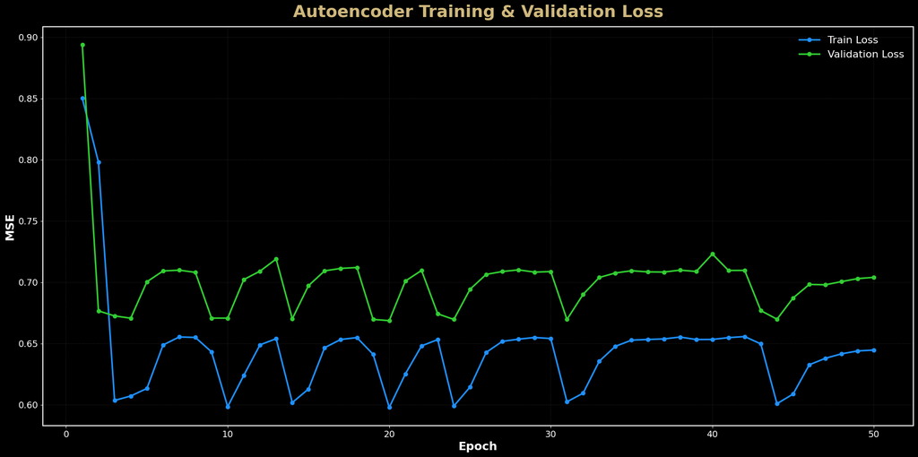

```
Figure saved to (Linux): /home/treinart/projects/lyft-unsupervised/artifacts/figures/20250917_213734_autoencoder_loss_curve.png
Figure saved to (Win):   /mnt/c/Users/travi/Documents/Training/Colorado/MS-AI/CSCA 5632 Final Project/artifacts/figures/20250917_213734_autoencoder_loss_curve.png
```

```python
# This cell will only run if the full computation is enabled.
if RUN_MODEL_TRAINING:
    # Create DataFrame from Training History
    history_df = pd.DataFrame(history)

    # Create and Style the Plot
    fig, ax = plt.subplots(figsize=(20, 10), facecolor="black")
    ax.set_facecolor("black")
    ax.plot(history_df["epoch"], history_df["train_loss"], label="Train Loss", color='dodgerblue', lw=2.5, marker='o')
    ax.plot(history_df["epoch"], history_df["valid_loss"], label="Validation Loss", color='limegreen', lw=2.5, marker='o')
    ax.set_title("Autoencoder Training & Validation Loss", fontsize=26, color="#CFB87C", fontweight="bold", pad=15)
    ax.set_xlabel("Epoch", fontsize=18, color="white", fontweight="bold")
    ax.set_ylabel("MSE", fontsize=18, color="white", fontweight="bold")
    ax.tick_params(colors="white", labelsize=14)
    for spine in ax.spines.values():
        spine.set_edgecolor("white")
        spine.set_linewidth(1.5)
    ax.legend(frameon=False, labelcolor="white", fontsize=16)
    ax.grid(color='gray', linestyle='--', linewidth=0.3, alpha=0.5)

    # Save the Figure
    save_fig(fig, "autoencoder_loss_curve")
else:
    print("--- Skipped: Loading from cache ---")
```

### 7.8 Embedding Extraction

With the model trained, the encoder half is used as a feature extractor. Every data window is passed through the encoder to generate its corresponding latent space embedding (`z`). These per-window embeddings are then aggregated by averaging to create a single feature vector for each unique agent track.

```python
# This cell will only run if the full computation is enabled.
if RUN_MODEL_TRAINING:
    # Extract Embeddings from the Trained Model
    full_ds = WindowDS(X_windows)
    full_loader = DataLoader(full_ds, batch_size=BATCH_SIZE * 2, shuffle=False, num_workers=1)
    model.eval()
    all_embeddings = []
    with torch.no_grad():
        for x_batch in tqdm(full_loader, desc="Extracting Window Embeddings", unit="batch"):
            x_batch = x_batch.to(device)
            with torch.cuda.amp.autocast(enabled=(device.type == "cuda")):
                _, z = model(x_batch)
            all_embeddings.append(z.cpu().numpy())
    Z_windows = np.vstack(all_embeddings)

    # Create Per-Window Embedding DataFrame
    win_embed_df = window_keys_df.copy()
    for j in range(Z_DIM):
        win_embed_df[f"z{j:03d}"] = Z_windows[:, j]

    # Aggregate to Track-Level Embeddings
    track_embeddings_df = (win_embed_df.drop("start_frame", axis=1)
                           .groupby(["scene_id", "track_id"])
                           .mean()
                           .reset_index())

    # Save Final Artifacts for Section 11
    print("\n--- Saving final track embeddings for later use ---")
    track_embeddings_df.to_parquet(ARTIFACT_DIR / "pipeline_b_track_embeddings.parquet", index=False)
    print(f"Saved to: {ARTIFACT_DIR / 'pipeline_b_track_embeddings.parquet'}")

    # Save Timestamped Artifacts for Caching
    print("\n--- Caching timestamped artifacts for this run ---")
    _save_df(track_embeddings_df, "ae_track_embeddings_pipeline_b")

    # Display a Summary
    preview = pd.DataFrame({"measure": ["windows", "tracks", "latent_dim"], "estimate": [len(win_embed_df), len(track_embeddings_df), Z_DIM]})
    display(style_section_table(preview))
else:
    print("--- Skipped: Loading from cache ---")
```

```
--- Saving final track embeddings for later use ---
Saved to: /home/treinart/projects/lyft-unsupervised/artifacts/pipeline_b_track_embeddings.parquet

--- Caching timestamped artifacts for this run ---
```

| measure | estimate |
| --- | --- |
| windows | 404919 |
| tracks | 9944 |
| latent_dim | 128 |

### 7.9 2D UMAP Visualization of Embeddings

To visualize the structure of the learned feature space, UMAP is used to project the high-dimensional track embeddings down to a 2D "behavior map." On this map, trajectories with similar learned features will appear close together. The points are colored by the agent's mean speed to help interpret the resulting structure.

```
----------------------------------------------------------------------

Shapes → Z_windows: (404919, 128) | Zt (tracks x latent): (9944, 128)

----------------------------------------------------------------------

Total tracks: 9,944 | Using 1,173 moving tracks for UMAP.
UMAP(min_dist=0.2, n_jobs=1, n_neighbors=150, random_state=42, verbose=True)
Wed Sep 17 21:37:53 2025 Construct fuzzy simplicial set
Wed Sep 17 21:37:53 2025 Finding Nearest Neighbors
Wed Sep 17 21:37:55 2025 Finished Nearest Neighbor Search
Wed Sep 17 21:37:55 2025 Construct embedding
```

```
Epochs completed:   0%|            0/500 [00:00]
```

```
	completed  0  /  500 epochs
	completed  50  /  500 epochs
	completed  100  /  500 epochs
	completed  150  /  500 epochs
	completed  200  /  500 epochs
	completed  250  /  500 epochs
	completed  300  /  500 epochs
	completed  350  /  500 epochs
	completed  400  /  500 epochs
	completed  450  /  500 epochs
Wed Sep 17 21:37:57 2025 Finished embedding
```

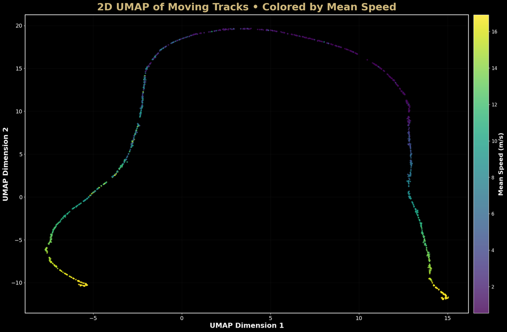

```
Figure saved to (Linux): /home/treinart/projects/lyft-unsupervised/artifacts/figures/20250917_213757_ae_umap_2d_moving_tracks.png
Figure saved to (Win):   /mnt/c/Users/travi/Documents/Training/Colorado/MS-AI/CSCA 5632 Final Project/artifacts/figures/20250917_213757_ae_umap_2d_moving_tracks.png
```

```python
# Prepare Data for Visualization
Zt = track_embeddings_df.filter(regex=r"^z\d+$").to_numpy(dtype=np.float32)
mean_speed_features = feat_df_capped[["scene_id", "track_id", "mean_speed"]]
color_data_df = track_embeddings_df.merge(mean_speed_features, on=["scene_id", "track_id"], how="left")
ms = color_data_df["mean_speed"].to_numpy(dtype=np.float32)

# Standardize the embeddings before visualization
mu = Zt.mean(axis=0); sd = Zt.std(axis=0) + 1e-6
Zt = (Zt - mu) / sd

print("-" * 70 + "\n")
print(f"Shapes → Z_windows: {Z_windows.shape} | Zt (tracks x latent): {Zt.shape}")
print("\n" + "-" * 70 + "\n")

# Filter out Stationary Tracks for a clearer plot
MOVE_SPEED_THRESHOLD = 0.5
moving_mask = ms > MOVE_SPEED_THRESHOLD
Zt_moving = Zt[moving_mask]
ms_moving = ms[moving_mask]
print(f"Total tracks: {len(Zt):,} | Using {len(Zt_moving):,} moving tracks for UMAP.")

# Run 2D UMAP
reducer = umap.UMAP(
    n_neighbors=150,
    min_dist=0.2,
    metric="euclidean",
    random_state=SEED,
    n_components=2,
    verbose=True
)
Z2_moving = reducer.fit_transform(Zt_moving)

# Plot the 2D Behavior Map
vmin, vmax = np.nanpercentile(ms_moving, 2), np.nanpercentile(ms_moving, 98)
fig, ax = plt.subplots(figsize=(20, 12), facecolor="black")
ax.set_facecolor("black")
sc = ax.scatter(
    Z2_moving[:, 0], Z2_moving[:, 1],
    c=ms_moving, cmap="viridis", vmin=vmin, vmax=vmax,
    s=15, alpha=0.8, edgecolors="none"
)
ax.set_title("2D UMAP of Moving Tracks • Colored by Mean Speed", fontsize=26, color="#CFB87C", fontweight="bold", pad=12)
ax.set_xlabel("UMAP Dimension 1", fontsize=18, color="white", fontweight="bold")
ax.set_ylabel("UMAP Dimension 2", fontsize=18, color="white", fontweight="bold")
ax.tick_params(colors="white", labelsize=14)
for sp in ax.spines.values():
    sp.set_edgecolor("white"); sp.set_linewidth(1.5)
ax.grid(color="white", alpha=0.08, linewidth=0.5)
cb = plt.colorbar(sc, ax=ax, pad=0.01)
cb.set_label("Mean Speed (m/s)", color="white", fontsize=16, fontweight="bold")
cb.ax.tick_params(colors="white", labelsize=12)
cb.outline.set_edgecolor("white")
save_fig(fig, "ae_umap_2d_moving_tracks")
```

### 7.10 3D UMAP Visualization of Embeddings

This cell provides an alternative, three-dimensional UMAP projection of the learned embeddings. The 3D view can sometimes reveal structural details, depth, or relationships between clusters that are not as apparent in the 2D visualization.

```
UMAP(min_dist=0.2, n_components=3, n_jobs=1, n_neighbors=150, random_state=42, verbose=True)
Wed Sep 17 21:38:01 2025 Construct fuzzy simplicial set
Wed Sep 17 21:38:02 2025 Finding Nearest Neighbors
Wed Sep 17 21:38:02 2025 Finished Nearest Neighbor Search
Wed Sep 17 21:38:02 2025 Construct embedding
```

```
Epochs completed:   0%|            0/500 [00:00]
```

```
	completed  0  /  500 epochs
	completed  50  /  500 epochs
	completed  100  /  500 epochs
	completed  150  /  500 epochs
	completed  200  /  500 epochs
	completed  250  /  500 epochs
	completed  300  /  500 epochs
	completed  350  /  500 epochs
	completed  400  /  500 epochs
	completed  450  /  500 epochs
Wed Sep 17 21:38:03 2025 Finished embedding
```

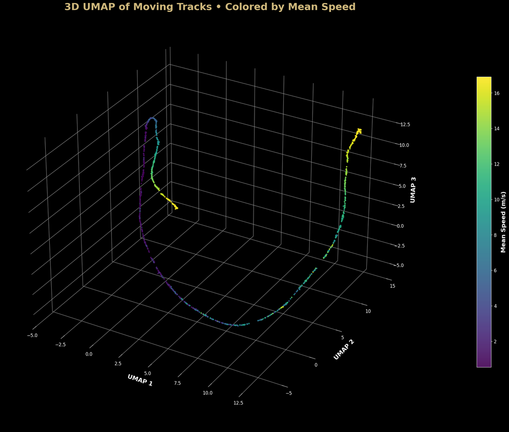

```
Figure saved to (Linux): /home/treinart/projects/lyft-unsupervised/artifacts/figures/20250917_213803_ae_umap_3d_track_embeddings.png
Figure saved to (Win):   /mnt/c/Users/travi/Documents/Training/Colorado/MS-AI/CSCA 5632 Final Project/artifacts/figures/20250917_213803_ae_umap_3d_track_embeddings.png
```

```python
# Run 3D UMAP on the same standardized embeddings
reducer3 = umap.UMAP(
    n_neighbors=150,
    min_dist=0.2,
    metric="euclidean",
    random_state=SEED,
    n_components=3,
    verbose=True
)
Z3_moving = reducer3.fit_transform(Zt_moving) # Use the same 'moving' subset

# Create the 3D Plot
fig = plt.figure(figsize=(22, 16), facecolor="black")
ax = fig.add_subplot(111, projection="3d")
sc = ax.scatter(
    Z3_moving[:, 0], Z3_moving[:, 1], Z3_moving[:, 2],
    c=ms_moving, s=15, cmap="viridis", vmin=vmin, vmax=vmax,
    alpha=0.9, edgecolors="none"
)

# Style the 3D Plot
ax.set_facecolor("black")
ax.xaxis.set_pane_color((0, 0, 0, 1)); ax.yaxis.set_pane_color((0, 0, 0, 1)); ax.zaxis.set_pane_color((0, 0, 0, 1))
ax.set_title("3D UMAP of Moving Tracks • Colored by Mean Speed", fontsize=26, color="#CFB87C", fontweight="bold", pad=12)
ax.set_xlabel("UMAP 1", fontsize=16, color="white", fontweight="bold", labelpad=10)
ax.set_ylabel("UMAP 2", fontsize=16, color="white", fontweight="bold", labelpad=10)
ax.set_zlabel("UMAP 3", fontsize=16, color="white", fontweight="bold", labelpad=10)
ax.tick_params(axis='x', colors='white', labelsize=12)
ax.tick_params(axis='y', colors='white', labelsize=12)
ax.tick_params(axis='z', colors='white', labelsize=12)
cb = fig.colorbar(sc, ax=ax, pad=0.1, shrink=0.7)
cb.set_label("Mean Speed (m/s)", color="white", fontsize=16, fontweight="bold")
cb.ax.tick_params(colors="white", labelsize=12)
cb.outline.set_edgecolor("white")

# Save the Figure
save_fig(fig, "ae_umap_3d_track_embeddings")
```

### **Observation: Deep Learning Feature Extraction Results**

Pipeline B tests whether a model can learn motion features directly from the data. Getting from idea to working system was iterative. Choices on windowing, loading, and optimization mattered as much as the network.

#### The Engineering Journey: A Rationale for the Final Hyperparameters

I started with long sequences and big batches and assumed the GPU would carry it. It didn’t.

- **First, the batch size.** Very large batches kept the GPU busy but cut gradient updates per epoch to a trickle. The goal is a strong embedding, not fast epochs. Setting **`BATCH_SIZE=256`** delivered about **1,414 steps/epoch**, plenty of learning signal, high GPU utilization, and no OOM.
- **Next, the `DataLoader`.** Multiprocessing loaders in WSL2 threw `AssertionError: can only test a child process` on teardown. I set **`num_workers=1`** with **`persistent_workers=True`**. That kept the pipe stable and still prefetched enough to feed the GPU.
- **Finally, the sequence length.** I first tried **`WIN_LEN=64`** to capture broader behavior. That starved the dataset; almost no tracks were long enough to produce windows. The fix was **`WIN_LEN=24`**. With 24-frame windows the dataset became usable and diverse, and the model learned patterns like turns and stop-go without collapsing.

This set of changes produced the stable, effective configuration used in the pipeline.

#### The Comeback from Section 8

After finishing what I thought was a successful Section 7 and moving to clustering in Section 8. Every score table returned NaN. A sanity print showed that the embedding matrix had been dropped to nothing after filtering zero vectors. That failure pointed back to Section 7.

- **Root cause.** With **`WIN_LEN=64`**, the window summary read **Total Tracks = 64,625**, **Tracks with Valid Windows = 2**. Almost no training signal. The decoder learned a trivial zero solution given the setup. With almost no track diversity, the latent collapsed.
- **The Fix.** Reduce `WIN_LEN` to **24**, rebuild windows, split by track, standardize on the train split. Keep the GRU AE but switch to **MSELoss**, add **teacher forcing** with a residual projection, use **OneCycleLR**, gradient clipping, small input noise, and proper initialization.
- **Outcome:**
  - Healthy dataset and training: **9,944** unique tracks, **362,231** train windows, **42,688** valid windows.
  - Latent checks showed non-zero variance across all **128** dimensions.
  - Section 7 now feeds Section 8 for a full embedding set without NaNs.

#### Performance: The Case for GPU Acceleration

[figure not shown]

As the performance monitor shows, this process saturated the NVIDIA 4070 GPU, maintaining near 99% utilization. A comparable run on a CPU would be an order of magnitude slower, likely taking several hours and making rapid iteration impractical. GPU acceleration was not just a convenience; it was a necessity for this approach.

#### Interpreting the results

**Loss curve “wobble” and why it is fine**

The loss sits in a narrow band. Train settles around **0.60–0.66** and validation around **0.67–0.71**, with gentle dips. Three things explain the shape:

1. **OneCycleLR** warms up then decays the learning rate, which nudges the curve around a floor instead of a straight drop.
2. **Input noise** and **dropout** change the effective data each epoch.
3. **Shuffle with `drop_last=True`** changes the exact window mix per epoch.

The checks that matter all pass: validation tracks the same band as training, there is no divergence, and the latent sanity shows variance across all dimensions with **zero** dead dims. This is stable training, not failure.

**Latent quality**

- **Final Train Loss:** **0.64467**
- **Final Valid Loss:** **0.70400**
- **Recon MSE (batch):** **0.03536**
- **Latent per-dim std:** mean **0.0105**, min **0.0075**, max **0.0225**
- **Zero-ish dims (<1e-3):** **0%**

#### Data analysis snapshot

- **Windows created:** **404,919**
- **Tracks represented:** **9,944**
- **Moving tracks used for UMAP:** **1,173**
- **Latent dimension:** **128**
- **Steps per epoch:** **1,414** (train) and **167** (valid)
- **Average epoch time:** **21.69 s**
- **Throughput:** **~65 steps/s**
- **Artifacts:** `pipeline_b_track_embeddings.parquet` (saved for Section 8)

**Conclusion**  
Pipeline B now produces a solid, non-degenerate embedding space. The loss is flat but stable, the latent has healthy variance, and the UMAP shows an ordered behavior manifold with a clear speed gradient. With these embeddings saved, the same clustering and model-selection playbook from Pipeline A can run on learned features to test whether they separate behaviors more cleanly.

## Section 8: Pipeline B - Clustering with Learned Embeddings

This section executes the modeling phase for Pipeline B. The goal is to apply the same clustering methodology from Section 6 to the new, learned embeddings from the autoencoder. By using an identical evaluation process, we can conduct a direct, fair comparison to determine whether the deep learning representations lead to a more effective or insightful set of behavioral clusters than the hand-engineered features.

### Section Plan:

**Checkpoint & Loader:** Option to skip computation and load the latest cached artifacts.

**Data Preparation:** Load and verify the autoencoder track embeddings from Section 7.

**KMeans Hyperparameter Sweep:** Systematically test a range of cluster counts (k) for KMeans.

**GMM Hyperparameter Sweep:** Test a range of components and covariance types for Gaussian Mixture Models.

**HDBSCAN Hyperparameter Sweep:** Explore the parameter space for the density-based HDBSCAN model.

**Stability Analysis:** Evaluate the stability of the best KMeans and GMM models using bootstrap ARI.

**Final Model Selection:** Use the same weighted scorecard from Pipeline A to select the overall winning model.

**Fit Final Model:** Train the winning model on the full set of embeddings and assign final cluster labels.

**Interpret Clusters (Profiling):** Analyze the median classical feature values for each new cluster to build their "personas".

**Qualitative Validation:** Plot sample trajectories from each cluster for a final, visual confirmation of the results.

### 8.1 Checkpoint: Run Full Section or Load from Cache

This cell acts as a checkpoint for the Pipeline B modeling section. The hyperparameter sweeps are time-consuming. Set the flag below to control the behavior of this section.

**`True`:** Run the full clustering sweeps and analysis for the autoencoder embeddings.

**`False`:** Skip the long computations and load the final results from a previous run.

```python
# Set to True to run the time-consuming clustering sweeps.
# Set to False to skip computation and load the final results from a previous run.
RUN_AE_CLUSTERING = True

if not RUN_AE_CLUSTERING:
    print("--- Skipped: Loading final Pipeline B clustering artifacts from cache ---")
    try:
        # Load the final cluster assignments, profiles, and model metadata from stable files
        final_clusters_df_ae = pd.read_parquet(ARTIFACT_DIR / "pipeline_b_cluster_assignments.parquet")
        cluster_profiles_ae = pd.read_parquet(ARTIFACT_DIR / "pipeline_b_cluster_profiles.parquet")
        with open(ARTIFACT_DIR / "pipeline_b_final_model_meta.json", 'r') as f:
            best_model_params_ae = json.load(f)

        # Also load the raw embeddings needed for the final visualization
        track_embeddings_df = pd.read_parquet(ARTIFACT_DIR / "pipeline_b_track_embeddings.parquet")

        print(f"Loaded {len(final_clusters_df_ae):,} cluster assignments for {best_model_params_ae['k']} clusters.")
        print(f"Winning model type: {best_model_params_ae['model_type']}")
        print("\n--- Successfully loaded artifacts. Ready to proceed to Section 9 ---")
    except FileNotFoundError:
        print("\n--- ERROR: No final artifacts found. Please set RUN_AE_CLUSTERING to True and run the full section ---")
        RUN_AE_CLUSTERING = True
else:
    print("--- RUN_AE_CLUSTERING is True. Proceeding with full computation. ---")
```

```
--- RUN_AE_CLUSTERING is True. Proceeding with full computation. ---
```

### 8.2 Data Preparation

This first step loads the track-level embeddings generated by the autoencoder in Section 7. A final quality assurance check is performed to verify the data's shape and prepare the embedding matrix for the clustering algorithms.

```python
# This cell will only run if the full computation is enabled.
if RUN_AE_CLUSTERING:
    # Load and Prepare the Learned Embeddings
    assert 'track_embeddings_df' in globals() and not track_embeddings_df.empty, "Missing track_embeddings_df from Section 7"
    embedding_cols = track_embeddings_df.filter(regex=r"^z\d+$").columns
    Z_df = track_embeddings_df[embedding_cols].copy()
    Z_df.replace([np.inf, -np.inf], np.nan, inplace=True)
    Z_df.fillna(Z_df.mean(), inplace=True)
    Z_ae_raw = Z_df.to_numpy(dtype=np.float32)
    track_index_raw = track_embeddings_df[["scene_id", "track_id"]].copy()

    # Filter out Rows that are All Zeros
    non_zero_mask = np.any(Z_ae_raw != 0, axis=1)
    Z_ae = Z_ae_raw[non_zero_mask]
    track_index = track_index_raw[non_zero_mask].reset_index(drop=True)

    # Print a Confirmation Summary
    print("-"*70)
    print("\n--- Autoencoder Embeddings Ready for Clustering ---")
    print(f"Embedding matrix shape: {Z_ae.shape}")
    print(f"Original tracks:        {len(Z_ae_raw):,}")
    print(f"Removed zero-vectors:   {len(Z_ae_raw) - len(Z_ae):,}")
    print(f"Final tracks for use:   {len(Z_ae):,}")
    print("\n" + "-"*70)
else:
    print("--- Skipped: Loading from cache ---")
```

```
----------------------------------------------------------------------

--- Autoencoder Embeddings Ready for Clustering ---
Embedding matrix shape: (9944, 128)
Original tracks:        9,944
Removed zero-vectors:   0
Final tracks for use:   9,944

----------------------------------------------------------------------
```

### 8.3 KMeans Hyperparameter Sweep

The KMeans sweep is performed on the learned embeddings to find the optimal number of clusters (k). The process is identical to the one in Pipeline A to ensure a fair comparison, evaluating cluster quality with the same three internal validation metrics across a range of k values.

```
--- KMeans Metric Summary (AE Embeddings) ---
```

| k | silhouette_mean | silhouette_std | calinski_harabasz_mean | calinski_harabasz_std | davies_bouldin_mean | davies_bouldin_std |
| --- | --- | --- | --- | --- | --- | --- |
| 4 | 0.934755 | 0.000077 | 82409.233358 | 3.447161 | 0.319611 | 0.000208 |
| 6 | 0.914499 | 0.013736 | 99062.709544 | 14930.161977 | 0.418017 | 0.019119 |
| 8 | 0.902638 | 0.004081 | 125371.764116 | 2193.608809 | 0.456663 | 0.010323 |
| 10 | 0.887206 | 0.024312 | 143047.685925 | 16248.695291 | 0.475481 | 0.013620 |
| 12 | 0.870497 | 0.017788 | 170188.943022 | 5887.532157 | 0.485695 | 0.005460 |
| 14 | 0.858184 | 0.015490 | 190884.156283 | 13993.947024 | 0.481952 | 0.010624 |
| 16 | 0.851574 | 0.011602 | 226064.274231 | 8717.045115 | 0.473770 | 0.003484 |
| 20 | 0.837887 | 0.004645 | 284227.976515 | 3157.856614 | 0.483541 | 0.004633 |
| 24 | 0.813781 | 0.010890 | 326428.410017 | 10030.846500 | 0.489135 | 0.004276 |

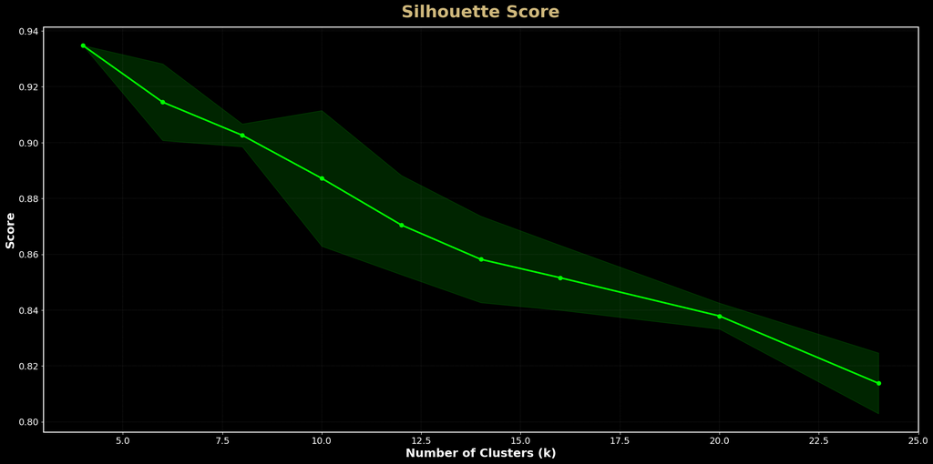

```
Figure saved to (Linux): /home/treinart/projects/lyft-unsupervised/artifacts/figures/20250917_213943_kmeans_sweep_ae_silhouette.png
Figure saved to (Win):   /mnt/c/Users/travi/Documents/Training/Colorado/MS-AI/CSCA 5632 Final Project/artifacts/figures/20250917_213943_kmeans_sweep_ae_silhouette.png
```

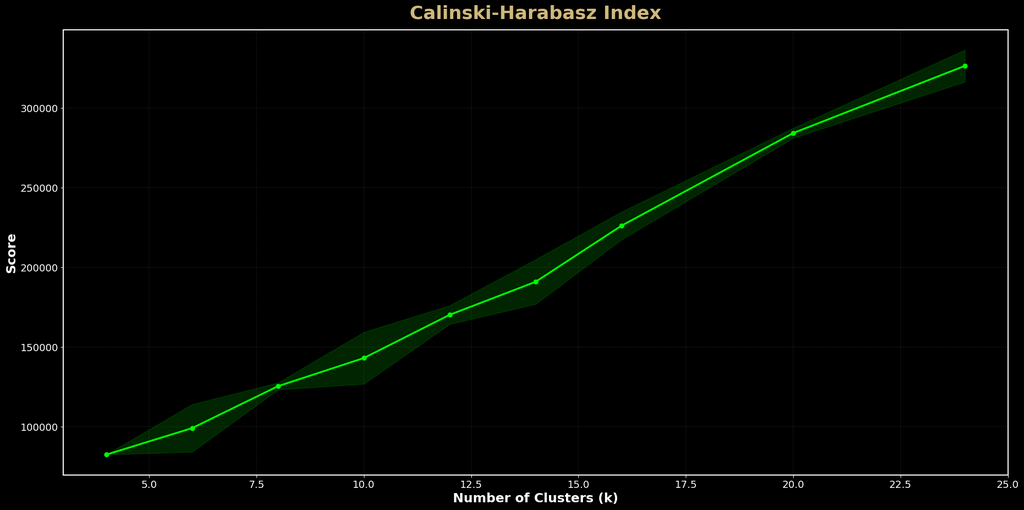

```
Figure saved to (Linux): /home/treinart/projects/lyft-unsupervised/artifacts/figures/20250917_213943_kmeans_sweep_ae_calinski_harabasz.png
Figure saved to (Win):   /mnt/c/Users/travi/Documents/Training/Colorado/MS-AI/CSCA 5632 Final Project/artifacts/figures/20250917_213943_kmeans_sweep_ae_calinski_harabasz.png
```

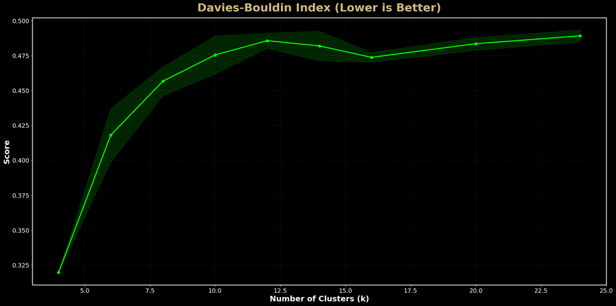

```
Figure saved to (Linux): /home/treinart/projects/lyft-unsupervised/artifacts/figures/20250917_213943_kmeans_sweep_ae_davies_bouldin.png
Figure saved to (Win):   /mnt/c/Users/travi/Documents/Training/Colorado/MS-AI/CSCA 5632 Final Project/artifacts/figures/20250917_213943_kmeans_sweep_ae_davies_bouldin.png
```

```python
# This cell will only run if the full computation is enabled.
if RUN_AE_CLUSTERING:
    # Define Sweep Parameters
    K_VALUES = [4, 6, 8, 10, 12, 14, 16, 20, 24]
    RANDOM_SEEDS = [0, 1, 2, 3, 4]

    # Run the KMeans Sweep
    kmeans_results_ae = []
    params = list(product(K_VALUES, RANDOM_SEEDS))
    for k, seed in tqdm(params, desc="Running KMeans Sweep (AE)"):
        kmeans = KMeans(n_clusters=k, n_init="auto", random_state=seed)
        labels = kmeans.fit_predict(Z_ae)
        try: sil = silhouette_score(Z_ae, labels, metric="euclidean")
        except ValueError: sil = np.nan
        try: ch = calinski_harabasz_score(Z_ae, labels)
        except ValueError: ch = np.nan
        try: db = davies_bouldin_score(Z_ae, labels)
        except ValueError: db = np.nan
        kmeans_results_ae.append({"k": k, "seed": seed, "silhouette": sil, "calinski_harabasz": ch, "davies_bouldin": db})
    kmeans_sweep_df_ae = pd.DataFrame(kmeans_results_ae)

    # Aggregate and Display Results
    kmeans_agg_df_ae = (kmeans_sweep_df_ae.groupby("k")
                        .agg(silhouette_mean=("silhouette", "mean"), silhouette_std=("silhouette", "std"),
                             calinski_harabasz_mean=("calinski_harabasz", "mean"), calinski_harabasz_std=("calinski_harabasz", "std"),
                             davies_bouldin_mean=("davies_bouldin", "mean"), davies_bouldin_std=("davies_bouldin", "std")).reset_index())
    print("\n--- KMeans Metric Summary (AE Embeddings) ---")
    display(style_section_table(kmeans_agg_df_ae))

    # Plot the Metric Curves
    metrics_to_plot = {"silhouette": "Silhouette Score", "calinski_harabasz": "Calinski-Harabasz Index", "davies_bouldin": "Davies-Bouldin Index (Lower is Better)"}
    for metric, title in metrics_to_plot.items():
        fig, ax = plt.subplots(figsize=(20, 10), facecolor="black")
        ax.set_facecolor("black")
        subset = kmeans_agg_df_ae
        if f"{metric}_mean" in subset.columns and subset[f"{metric}_mean"].notna().any():
            ax.plot(subset["k"], subset[f"{metric}_mean"], marker='o', linestyle='-', color='lime', lw=2.5)
            ax.fill_between(subset["k"], subset[f"{metric}_mean"] - subset[f"{metric}_std"], subset[f"{metric}_mean"] + subset[f"{metric}_std"], alpha=0.15, color='lime')
        ax.set_title(title, fontsize=26, color="#CFB87C", fontweight="bold", pad=15)
        ax.set_xlabel("Number of Clusters (k)", fontsize=18, color="white", fontweight="bold")
        ax.set_ylabel("Score", fontsize=18, color="white", fontweight="bold")
        ax.tick_params(colors="white", labelsize=14)
        for spine in ax.spines.values(): spine.set_edgecolor("white"); spine.set_linewidth(1.5)
        ax.grid(color='gray', linestyle='--', linewidth=0.3, alpha=0.5)
        save_fig(fig, f"kmeans_sweep_ae_{metric}")
else:
    print("--- Skipped: Loading from cache ---")
```

### 8.4 GMM Hyperparameter Sweep

The Gaussian Mixture Model sweep is repeated on the learned embeddings, testing a range of component counts and covariance types. The results, measured by BIC, AIC, and Silhouette Score, will be compared to those from Pipeline A to see how the change in feature space affects the performance of this more flexible clustering model.

```
--- GMM BIC Winners (per covariance type) ---
```

| Covariance | k | BIC ↓ | AIC ↓ | Silhouette ↑ |
| --- | --- | --- | --- | --- |
| diag | 20 | -6,219,198 | -6,256,224 | 0.848 |
| full | 4 | -6,104,983 | -6,346,622 | 0.792 |

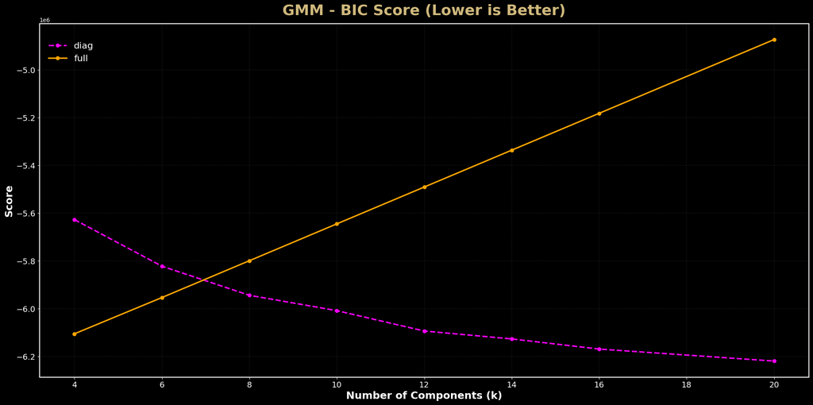

```
Figure saved to (Linux): /home/treinart/projects/lyft-unsupervised/artifacts/figures/20250917_220456_gmm_sweep_ae_bic.png
Figure saved to (Win):   /mnt/c/Users/travi/Documents/Training/Colorado/MS-AI/CSCA 5632 Final Project/artifacts/figures/20250917_220456_gmm_sweep_ae_bic.png
```

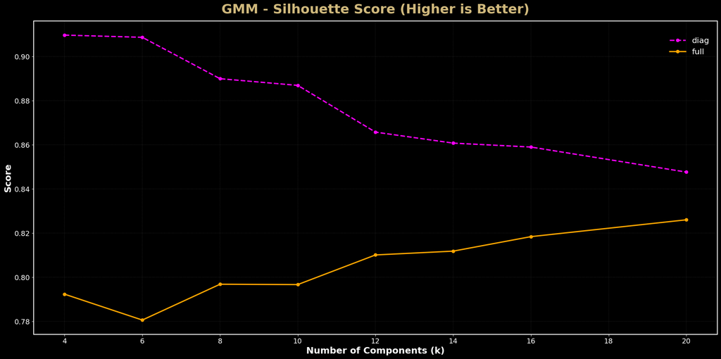

```
Figure saved to (Linux): /home/treinart/projects/lyft-unsupervised/artifacts/figures/20250917_220457_gmm_sweep_ae_silhouette.png
Figure saved to (Win):   /mnt/c/Users/travi/Documents/Training/Colorado/MS-AI/CSCA 5632 Final Project/artifacts/figures/20250917_220457_gmm_sweep_ae_silhouette.png
```

```python
# This cell will only run if the full computation is enabled.
if RUN_AE_CLUSTERING:
    # Define Sweep Parameters
    N_COMPONENTS = [4, 6, 8, 10, 12, 14, 16, 20]
    COVARIANCE_TYPES = ["full", "diag"]
    GMM_SEEDS = [0, 1, 2]

    # Run the GMM Sweep
    gmm_results_ae = []
    params = list(product(COVARIANCE_TYPES, N_COMPONENTS, GMM_SEEDS))
    for cov_type, k, seed in tqdm(params, desc="Running GMM Sweep (AE)"):
        gmm = GaussianMixture(n_components=k, covariance_type=cov_type, random_state=seed, reg_covar=1e-3)
        labels = gmm.fit_predict(Z_ae)
        try:
            sil = silhouette_score(Z_ae, labels, metric="euclidean")
            bic = gmm.bic(Z_ae)
            aic = gmm.aic(Z_ae)
        except ValueError:
            sil, bic, aic = np.nan, np.nan, np.nan
        gmm_results_ae.append({"covariance": cov_type, "k": k, "seed": seed, "silhouette": sil, "bic": bic, "aic": aic})
    gmm_sweep_df_ae = pd.DataFrame(gmm_results_ae)

    # Aggregate Results
    gmm_agg_df_ae = (gmm_sweep_df_ae.groupby(["covariance", "k"])
                     .agg(silhouette_mean=("silhouette", "mean"), bic_mean=("bic", "mean"), aic_mean=("aic", "mean")).reset_index())

    # Create and Display the BIC Winners Summary Table
    winners_df_ae = (gmm_agg_df_ae.sort_values("bic_mean", ascending=True)
                     .groupby("covariance", as_index=False)
                     .first()[["covariance", "k", "bic_mean", "aic_mean", "silhouette_mean"]])
    winners_pretty_ae = winners_df_ae.rename(columns={"covariance": "Covariance", "k": "k", "bic_mean": "BIC ↓", "aic_mean": "AIC ↓", "silhouette_mean": "Silhouette ↑"}).copy()
    winners_pretty_ae["BIC ↓"] = winners_pretty_ae["BIC ↓"].map(lambda x: "---" if pd.isna(x) else f"{x:,.0f}")
    winners_pretty_ae["AIC ↓"] = winners_pretty_ae["AIC ↓"].map(lambda x: "---" if pd.isna(x) else f"{x:,.0f}")
    winners_pretty_ae["Silhouette ↑"] = winners_pretty_ae["Silhouette ↑"].map(lambda x: "---" if pd.isna(x) else f"{x:.3f}")
    print("\n--- GMM BIC Winners (per covariance type) ---")
    display(style_section_table(winners_pretty_ae))

    # Plot the Metric Curves
    for metric, title in [("bic", "GMM - BIC Score (Lower is Better)"), ("silhouette", "GMM - Silhouette Score (Higher is Better)")]:
        fig, ax = plt.subplots(figsize=(20, 10), facecolor="black")
        ax.set_facecolor("black")
        styles = {"full": "-", "diag": "--"}; colors = {"full": 'orange', "diag": 'magenta'}
        for cov_type, group in gmm_agg_df_ae.groupby("covariance"):
            ax.plot(group["k"], group[f"{metric}_mean"], marker='o', linestyle=styles[cov_type], label=cov_type, color=colors[cov_type], lw=2.5)
        ax.set_title(title, fontsize=26, color="#CFB87C", fontweight="bold", pad=15)
        ax.set_xlabel("Number of Components (k)", fontsize=18, color="white", fontweight="bold")
        ax.set_ylabel("Score", fontsize=18, color="white", fontweight="bold")
        ax.tick_params(colors="white", labelsize=14)
        for spine in ax.spines.values(): spine.set_edgecolor("white"); spine.set_linewidth(1.5)
        ax.legend(frameon=False, labelcolor="white", fontsize=16, title="Covariance Type")
        ax.grid(color='gray', linestyle='--', linewidth=0.3, alpha=0.5)
        save_fig(fig, f"gmm_sweep_ae_{metric}")
else:
    print("--- Skipped: Loading from cache ---")
```

### 8.5 HDBSCAN Hyperparameter Sweep

The HDBSCAN sweep is repeated on the learned embeddings. This will show how the density-based algorithm behaves on the new feature space and allow for a comparison of the number of clusters found and the noise rate versus the results from Pipeline A.

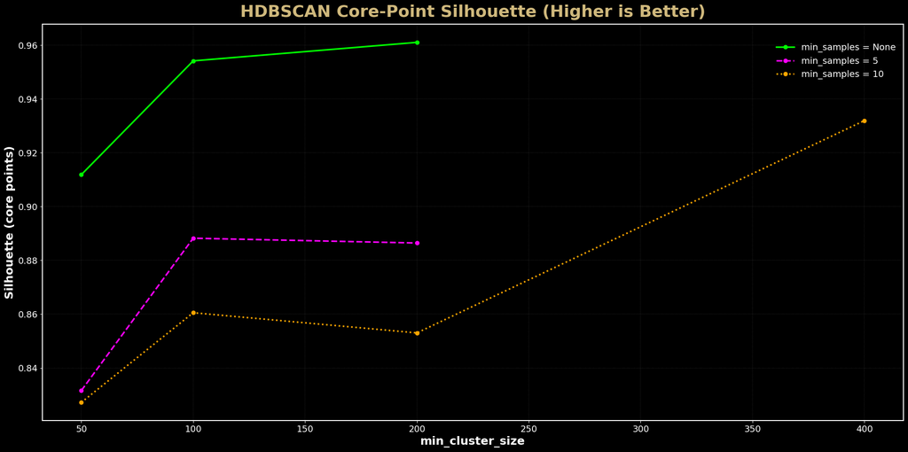

```
Figure saved to (Linux): /home/treinart/projects/lyft-unsupervised/artifacts/figures/20250917_220602_hdbscan_sweep_ae_silhouette.png
Figure saved to (Win):   /mnt/c/Users/travi/Documents/Training/Colorado/MS-AI/CSCA 5632 Final Project/artifacts/figures/20250917_220602_hdbscan_sweep_ae_silhouette.png
```

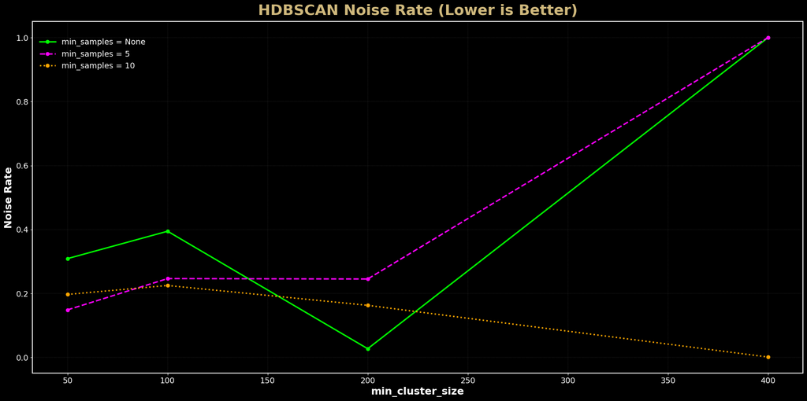

```
Figure saved to (Linux): /home/treinart/projects/lyft-unsupervised/artifacts/figures/20250917_220602_hdbscan_sweep_ae_noise.png
Figure saved to (Win):   /mnt/c/Users/travi/Documents/Training/Colorado/MS-AI/CSCA 5632 Final Project/artifacts/figures/20250917_220602_hdbscan_sweep_ae_noise.png

----------------------------------------------------------------------
HDBSCAN Sweep Summary (AE Embeddings)
```

| min_cluster_size | min_samples | clusters_found | noise_rate | silhouette_core |
| --- | --- | --- | --- | --- |
| 50 | -1 | 13 | 0.309031 | 0.911842 |
| 50 | 5 | 35 | 0.148833 | 0.831608 |
| 50 | 10 | 26 | 0.197104 | 0.827194 |
| 100 | -1 | 4 | 0.394610 | 0.954126 |
| 100 | 5 | 15 | 0.246581 | 0.888224 |
| 100 | 10 | 11 | 0.225060 | 0.860532 |
| 200 | -1 | 3 | 0.027353 | 0.961009 |
| 200 | 5 | 4 | 0.245374 | 0.886444 |
| 200 | 10 | 4 | 0.163013 | 0.853036 |
| 400 | -1 | 0 | 1.000000 | nan |
| 400 | 5 | 0 | 1.000000 | nan |
| 400 | 10 | 2 | 0.001408 | 0.931933 |

```python
# This cell will only run if the full computation is enabled.
if RUN_AE_CLUSTERING:
    # Define Sweep Parameters
    MIN_CLUSTER_SIZES = [50, 100, 200, 400]
    MIN_SAMPLES = [None, 5, 10]

    # Run the HDBSCAN Sweep
    hdbscan_results_ae = []
    params = list(product(MIN_CLUSTER_SIZES, MIN_SAMPLES))
    for mcs, ms in tqdm(params, desc="Running HDBSCAN Sweep (AE)"):
        clusterer = hdbscan.HDBSCAN(min_cluster_size=mcs, min_samples=ms, metric='euclidean')
        labels = clusterer.fit_predict(Z_ae)
        is_core_point = labels >= 0
        noise_rate = 1.0 - is_core_point.mean()
        n_clusters = len(set(labels)) - (1 if -1 in labels else 0)
        if n_clusters > 1:
            sil = silhouette_score(Z_ae[is_core_point], labels[is_core_point], metric="euclidean")
        else:
            sil = np.nan
        hdbscan_results_ae.append({"min_cluster_size": mcs, "min_samples": -1 if ms is None else ms, "clusters_found": n_clusters, "noise_rate": noise_rate, "silhouette_core": sil})
    hdbscan_sweep_df_ae = pd.DataFrame(hdbscan_results_ae)

    # Create Summary Plots for HDBSCAN Trade-offs
    ms_styles = {-1: "-", 5: "--", 10: ":"}
    ms_labels = {-1: "None", 5: "5", 10: "10"}
    ms_colors = {-1: 'lime', 5: 'magenta', 10: 'orange'}

    # Plot 1: Silhouette on Core Points
    fig, ax = plt.subplots(figsize=(20, 10), facecolor="black")
    ax.set_facecolor("black")
    for ms in sorted(hdbscan_sweep_df_ae["min_samples"].unique()):
        sub = hdbscan_sweep_df_ae[hdbscan_sweep_df_ae["min_samples"] == ms].sort_values("min_cluster_size")
        if len(sub):
            ax.plot(sub["min_cluster_size"], sub["silhouette_core"], marker="o", lw=2.5, linestyle=ms_styles.get(ms, "-"), color=ms_colors.get(ms, "white"), label=f"min_samples = {ms_labels.get(ms, str(ms))}")
    ax.set_title("HDBSCAN Core-Point Silhouette (Higher is Better)", fontsize=26, color="#CFB87C", fontweight="bold", pad=12)
    ax.set_xlabel("min_cluster_size", fontsize=18, color="white", fontweight="bold")
    ax.set_ylabel("Silhouette (core points)", fontsize=18, color="white", fontweight="bold")
    ax.tick_params(colors="white", labelsize=14)
    for sp in ax.spines.values(): sp.set_edgecolor("white"); sp.set_linewidth(1.5)
    ax.grid(color="gray", linestyle="--", linewidth=0.3, alpha=0.5)
    ax.legend(frameon=False, labelcolor="white", fontsize=14, title="min_samples")
    save_fig(fig, "hdbscan_sweep_ae_silhouette")

    # Plot 2: Noise Rate
    fig, ax = plt.subplots(figsize=(20, 10), facecolor="black")
    ax.set_facecolor("black")
    for ms in sorted(hdbscan_sweep_df_ae["min_samples"].unique()):
        sub = hdbscan_sweep_df_ae[hdbscan_sweep_df_ae["min_samples"] == ms].sort_values("min_cluster_size")
        if len(sub):
            ax.plot(sub["min_cluster_size"], sub["noise_rate"], marker="o", lw=2.5, linestyle=ms_styles.get(ms, "-"), color=ms_colors.get(ms, "white"), label=f"min_samples = {ms_labels.get(ms, str(ms))}")
    ax.set_title("HDBSCAN Noise Rate (Lower is Better)", fontsize=26, color="#CFB87C", fontweight="bold", pad=12)
    ax.set_xlabel("min_cluster_size", fontsize=18, color="white", fontweight="bold")
    ax.set_ylabel("Noise Rate", fontsize=18, color="white", fontweight="bold")
    ax.tick_params(colors="white", labelsize=14)
    for sp in ax.spines.values(): sp.set_edgecolor("white"); sp.set_linewidth(1.5)
    ax.grid(color="gray", linestyle="--", linewidth=0.3, alpha=0.5)
    ax.legend(frameon=False, labelcolor="white", fontsize=14, title="min_samples")
    save_fig(fig, "hdbscan_sweep_ae_noise")

    # Display the Results Table
    print("\n" + "-"*70)
    print("HDBSCAN Sweep Summary (AE Embeddings)")
    display(style_section_table(hdbscan_sweep_df_ae))
else:
    print("--- Skipped: Loading from cache ---")
```

### 8.6 Stability Analysis

The same bootstrap resampling analysis is performed on the best KMeans and GMM candidates from the learned embedding sweeps. This provides a direct, apples-to-apples comparison of model stability between Pipeline A and Pipeline B.

```python
# This cell will only run if the full computation is enabled.
if RUN_AE_CLUSTERING:
    # Identify Best Candidate Models from Sweeps
    best_km_params_ae = kmeans_agg_df_ae.loc[kmeans_agg_df_ae['silhouette_mean'].idxmax()]
    km_candidate_ae = {"k": int(best_km_params_ae["k"])}
    best_gmm_params_ae = gmm_agg_df_ae.loc[gmm_agg_df_ae['bic_mean'].idxmin()]
    gmm_candidate_ae = {"k": int(best_gmm_params_ae["k"]), "cov": best_gmm_params_ae["covariance"]}

    # Define the Bootstrap ARI Function
    def calculate_bootstrap_ari(model_type: str, params: dict, Z: np.ndarray, n_bootstraps: int = 10, frac: float = 0.8):
        n_samples = Z.shape[0]
        bootstrap_labels = []
        desc = f"Bootstrap ARI ({model_type.upper()})"
        for i in tqdm(range(n_bootstraps), desc=desc):
            rng = np.random.default_rng(SEED + i)
            indices = rng.choice(n_samples, size=int(frac * n_samples), replace=True)
            Z_sample = Z[indices]
            if model_type == "kmeans":
                model = KMeans(n_clusters=params["k"], n_init='auto', random_state=SEED)
            else: # gmm
                model = GaussianMixture(n_components=params["k"], covariance_type=params["cov"], random_state=SEED, reg_covar=1e-3)
            full_labels = np.full(n_samples, -1)
            sample_labels = model.fit_predict(Z_sample)
            full_labels[indices] = sample_labels
            bootstrap_labels.append(full_labels)
        ari_scores = []
        for i in range(n_bootstraps):
            for j in range(i + 1, n_bootstraps):
                common = (bootstrap_labels[i] >= 0) & (bootstrap_labels[j] >= 0)
                if common.sum() > 1:
                    ari_scores.append(ARI(bootstrap_labels[i][common], bootstrap_labels[j][common]))
        return np.mean(ari_scores) if ari_scores else np.nan, np.std(ari_scores) if ari_scores else np.nan

    # Run Stability Analysis
    print("--- Running Stability Analysis on AE Embeddings (Bootstrap ARI) ---")
    km_ari_mean_ae, km_ari_std_ae = calculate_bootstrap_ari("kmeans", km_candidate_ae, Z_ae)
    gm_ari_mean_ae, gm_ari_std_ae = calculate_bootstrap_ari("gmm", gmm_candidate_ae, Z_ae)
    stability_df_ae = pd.DataFrame([
        {"model": "KMeans", **km_candidate_ae, "ari_mean": km_ari_mean_ae, "ari_std": km_ari_std_ae},
        {"model": "GMM", **gmm_candidate_ae, "ari_mean": gm_ari_mean_ae, "ari_std": gm_ari_std_ae},
    ])
    print("\n--- Model Stability Summary (AE Embeddings) ---")
    display(style_section_table(stability_df_ae))
else:
    print("--- Skipped: Loading from cache ---")
```

```
--- Running Stability Analysis on AE Embeddings (Bootstrap ARI) ---
```

```
--- Model Stability Summary (AE Embeddings) ---
```

| model | k | ari_mean | ari_std | cov |
| --- | --- | --- | --- | --- |
| KMeans | 4 | 0.995925 | 0.002976 | nan |
| GMM | 20 | 0.970336 | 0.025697 | diag |

### 8.7 Final Model Selection

The final model for Pipeline B is selected using the exact same weighted scorecard from Section 6. This ensures a fair, consistent, and data-driven comparison, allowing us to directly contrast the top models from both the classical and the deep learning pipelines.

```python
# This cell will only run if the full computation is enabled.
if RUN_AE_CLUSTERING:
    # Consolidate All Candidate Models
    candidates_ae = []
    top_kmeans_ae = (kmeans_agg_df_ae.sort_values("silhouette_mean", ascending=False).nlargest(5, "silhouette_mean"))
    for _, row in top_kmeans_ae.iterrows():
        is_best_stable = (row["k"] == km_candidate_ae["k"])
        candidates_ae.append({"model": "KMeans", "k": int(row["k"]), "cov_type": None, "sil": row["silhouette_mean"], "ch": row["calinski_harabasz_mean"], "db": row["davies_bouldin_mean"], "bic": np.nan, "aic": np.nan, "ari_mean": km_ari_mean_ae if is_best_stable else np.nan})
    top_gmm_ae = (gmm_agg_df_ae.sort_values("bic_mean", ascending=True).groupby("covariance").head(5))
    for _, row in top_gmm_ae.iterrows():
        is_best_stable = (row["k"] == gmm_candidate_ae["k"] and row["covariance"] == gmm_candidate_ae["cov"])
        candidates_ae.append({"model": "GMM", "k": int(row["k"]), "cov_type": row["covariance"], "sil": row["silhouette_mean"], "ch": np.nan, "db": np.nan, "bic": row["bic_mean"], "aic": row["aic_mean"], "ari_mean": gm_ari_mean_ae if is_best_stable else np.nan})
    candidates_df_ae = pd.DataFrame(candidates_ae)

    # Create the Weighted Scorecard
    scorecard_df_ae = candidates_df_ae.copy()
    direction = {"sil": 1, "ch": 1, "db": -1, "bic": -1, "aic": -1, "ari_mean": 1}
    for m, sgn in direction.items():
        col = scorecard_df_ae[m]
        scorecard_df_ae[f"{m}_z"] = sgn * (col - col.mean()) / col.std()
    scorecard_df_ae = scorecard_df_ae.fillna(0)
    scorecard_df_ae["final_score"] = (1.5 * scorecard_df_ae["sil_z"] + 1.0 * scorecard_df_ae["ch_z"] + 1.0 * scorecard_df_ae["db_z"] + 1.0 * scorecard_df_ae["bic_z"] + 0.5 * scorecard_df_ae["aic_z"] + 2.0 * scorecard_df_ae["ari_mean_z"])

    # Display Final Ranking
    ranked_df_ae = scorecard_df_ae.sort_values("final_score", ascending=False).reset_index(drop=True)
    display_cols = ["model", "k", "cov_type", "final_score", "sil", "ari_mean", "bic", "db", "ch"]
    pretty_df = ranked_df_ae[display_cols].head(10).copy()

    # Define a robust formatter that handles NaNs and Zeros
    def format_pretty(x, precision=3, is_score=False, is_int=False):
        if pd.isna(x) or (isinstance(x, (int, float)) and abs(x) < 1e-9 and not is_score):
            return "---"
        if is_score: return f"{x:+.{precision}f}"
        if is_int: return f"{x:,.0f}"
        if isinstance(x, float): return f"{x:.{precision}f}"
        return x

    # Apply formatting
    pretty_df['cov_type'] = pretty_df['cov_type'].replace(0, "---").fillna("---")
    pretty_df['final_score'] = pretty_df['final_score'].apply(lambda v: format_pretty(v, is_score=True))
    for col in ["sil", "ari_mean", "db"]:
        pretty_df[col] = pretty_df[col].apply(lambda v: format_pretty(v))
    for col in ["ch", "bic"]:
        pretty_df[col] = pretty_df[col].apply(lambda v: format_pretty(v, is_int=True))

    print("--- Final Model Scorecard and Ranking (AE Embeddings) ---")
    display(style_section_table(pretty_df))

    # Select the Winning Model
    best_model_params_ae = ranked_df_ae.iloc[0].to_dict()
    print("\n" + "-"*70)
    print("--- WINNING MODEL CONFIGURATION (PIPELINE B) ---")
    print(f"  - Model: {best_model_params_ae['model']}")
    print(f"  - Number of Clusters (k): {int(best_model_params_ae['k'])}")
    if best_model_params_ae['model'] == 'GMM': print(f"  - Covariance Type: {best_model_params_ae['cov_type']}")
    print("-"*70)
else:
    print("--- Skipped: Loading from cache ---")
```

```
--- Final Model Scorecard and Ranking (AE Embeddings) ---
```

| model | k | cov_type | final_score | sil | ari_mean | bic | db | ch |
| --- | --- | --- | --- | --- | --- | --- | --- | --- |
| KMeans | 4 | --- | +4.377 | 0.935 | 0.996 | --- | 0.320 | 82,409 |
| KMeans | 6 | --- | +1.356 | 0.914 | --- | --- | 0.418 | 99,063 |
| KMeans | 8 | --- | +1.172 | 0.903 | --- | --- | 0.457 | 125,372 |
| KMeans | 12 | --- | +1.035 | 0.870 | --- | --- | 0.486 | 170,189 |
| GMM | 16 | diag | +0.934 | 0.859 | --- | -6,168,934 | --- | --- |
| KMeans | 10 | --- | +0.924 | 0.887 | --- | --- | 0.475 | 143,048 |
| GMM | 14 | diag | +0.575 | 0.861 | --- | -6,126,513 | --- | --- |
| GMM | 12 | diag | +0.402 | 0.866 | --- | -6,093,447 | --- | --- |
| GMM | 10 | diag | +0.244 | 0.887 | --- | -6,008,077 | --- | --- |
| GMM | 20 | diag | -0.326 | 0.848 | 0.970 | -6,219,198 | --- | --- |

```
----------------------------------------------------------------------
--- WINNING MODEL CONFIGURATION (PIPELINE B) ---
  - Model: KMeans
  - Number of Clusters (k): 4
----------------------------------------------------------------------
```

### 8.8 Fit Final Model & Assign Labels

```python
# This cell will only run if the full computation is enabled.
if RUN_AE_CLUSTERING:
    # Configure the Final Model
    k_final_ae = int(best_model_params_ae['k'])
    if best_model_params_ae['model'] == 'KMeans':
        final_model_ae = KMeans(n_clusters=k_final_ae, n_init='auto', random_state=SEED)
        model_meta = {"model_type": "KMeans", "k": k_final_ae}
    else: # GMM
        cov_final_ae = best_model_params_ae['cov_type']
        final_model_ae = GaussianMixture(n_components=k_final_ae, covariance_type=cov_final_ae, random_state=SEED, reg_covar=1e-4, init_params="kmeans", n_init=3, max_iter=500)
        model_meta = {"model_type": "GMM", "k": k_final_ae, "covariance_type": cov_final_ae}

    # Fit the Model and Get Final Labels
    print(f"--- Fitting final {best_model_params_ae['model']} model... ---")
    final_labels_ae = final_model_ae.fit_predict(Z_ae)

    # Assign Labels to Track Identifiers
    final_clusters_df_ae = track_index.copy()
    final_clusters_df_ae["cluster_id"] = final_labels_ae

    # Save Final Artifacts for Section 11
    print("\n--- Saving final Pipeline B artifacts for later use ---")
    final_clusters_df_ae.to_parquet(ARTIFACT_DIR / "pipeline_b_cluster_assignments.parquet", index=False)
    print(f"Saved to: {ARTIFACT_DIR / 'pipeline_b_cluster_assignments.parquet'}")
    with open(ARTIFACT_DIR / "pipeline_b_final_model_meta.json", "w") as f: json.dump(model_meta, f, indent=2)
    print(f"Saved to: {ARTIFACT_DIR / 'pipeline_b_final_model_meta.json'}")
else:
    print("--- Skipped: Loading from cache ---")
```

```
--- Fitting final KMeans model... ---

--- Saving final Pipeline B artifacts for later use ---
Saved to: /home/treinart/projects/lyft-unsupervised/artifacts/pipeline_b_cluster_assignments.parquet
Saved to: /home/treinart/projects/lyft-unsupervised/artifacts/pipeline_b_final_model_meta.json
```

### 8.9 Interpret Clusters: Quantitative Profiling

To understand the meaning of the clusters found using the learned embeddings, we profile them using the original, interpretable features from Pipeline A. By calculating the median classical feature values for each new cluster, we can build a numerical "persona" and directly compare the behavioral archetypes to those found in Section 6.

```
--- Cluster Feature Profiles (Median Values, AE Embeddings) ---
```

| mean_speed | p95_speed | std_speed | heading_change_rate | stop_ratio | straightness | duration_s |
| --- | --- | --- | --- | --- | --- | --- |
| 0.003656 | 0.000000 | 0.023416 | 0.318752 | 1.000000 | 0.129100 | 5.300000 |
| 12.060855 | 13.894132 | 2.272408 | 0.487360 | 0.022475 | 0.998720 | 6.200000 |
| 12.109538 | 13.907170 | 2.204817 | 0.198100 | 0.023810 | 0.999069 | 6.100000 |
| 5.326145 | 9.117313 | 1.811916 | 0.639075 | 0.030303 | 0.980174 | 7.600000 |

```
--- Saving final cluster profiles for later use ---
Saved to: /home/treinart/projects/lyft-unsupervised/artifacts/pipeline_b_cluster_profiles.parquet
```

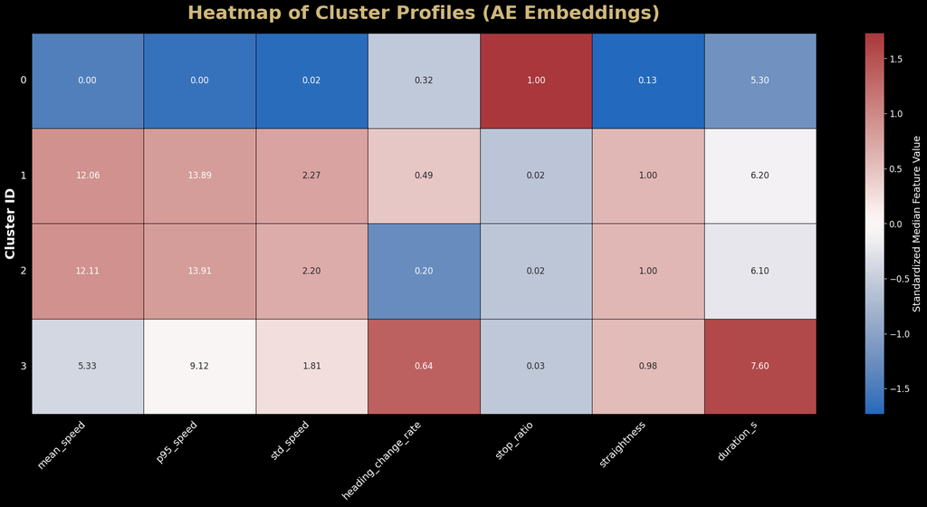

```
Figure saved to (Linux): /home/treinart/projects/lyft-unsupervised/artifacts/figures/20250917_220646_ae_cluster_profiles_heatmap.png
Figure saved to (Win):   /mnt/c/Users/travi/Documents/Training/Colorado/MS-AI/CSCA 5632 Final Project/artifacts/figures/20250917_220646_ae_cluster_profiles_heatmap.png
```

```python
# Create and Visualize Cluster Profiles
profiles_df_input_ae = final_clusters_df_ae.merge(feat_df_capped, on=["scene_id", "track_id"])
cluster_profiles_ae = (profiles_df_input_ae.groupby("cluster_id")[FINAL_FEATURE_COLS]
                       .median()
                       .sort_index())
print("--- Cluster Feature Profiles (Median Values, AE Embeddings) ---")
display(style_section_table(cluster_profiles_ae))

# Save Final Profiles for Section 11
print("\n--- Saving final cluster profiles for later use ---")
cluster_profiles_ae.to_parquet(ARTIFACT_DIR / "pipeline_b_cluster_profiles.parquet")
print(f"Saved to: {ARTIFACT_DIR / 'pipeline_b_cluster_profiles.parquet'}")

# Visualize Profiles with a Heatmap
profile_scaled_ae = StandardScaler().fit_transform(cluster_profiles_ae)
fig, ax = plt.subplots(figsize=(20, 10), facecolor="black")
sns.heatmap(
    profile_scaled_ae, annot=cluster_profiles_ae.to_numpy(), fmt=".2f", cmap="vlag",
    linewidths=0.5, linecolor='black', ax=ax, cbar_kws={"shrink": 1.0}, annot_kws={"size": 12}
)
ax.set_title("Heatmap of Cluster Profiles (AE Embeddings)", fontsize=26, color="#CFB87C", fontweight="bold", pad=20)
ax.set_xticklabels(cluster_profiles_ae.columns, rotation=45, ha="right", fontsize=14, color="white")
ax.set_yticklabels(cluster_profiles_ae.index, rotation=0, fontsize=14, color="white")
ax.set_ylabel("Cluster ID", fontsize=18, color="white", fontweight="bold")
cbar = ax.collections[0].colorbar
cbar.set_label("Standardized Median Feature Value", color="white", fontsize=14)
cbar.ax.tick_params(colors="white", labelsize=12)
cbar.outline.set_edgecolor("white")
save_fig(fig, "ae_cluster_profiles_heatmap")
```

### 8.10 Qualitative Validation: Trajectory Samples

The final step is a visual, qualitative check of the new clusters. A random sample of trajectories from each of the most populous clusters is plotted. By normalizing each trajectory to start at (0,0), we can overlay their shapes to visually inspect the characteristic pattern of movement for each group, confirming that the model has identified meaningful behaviors.

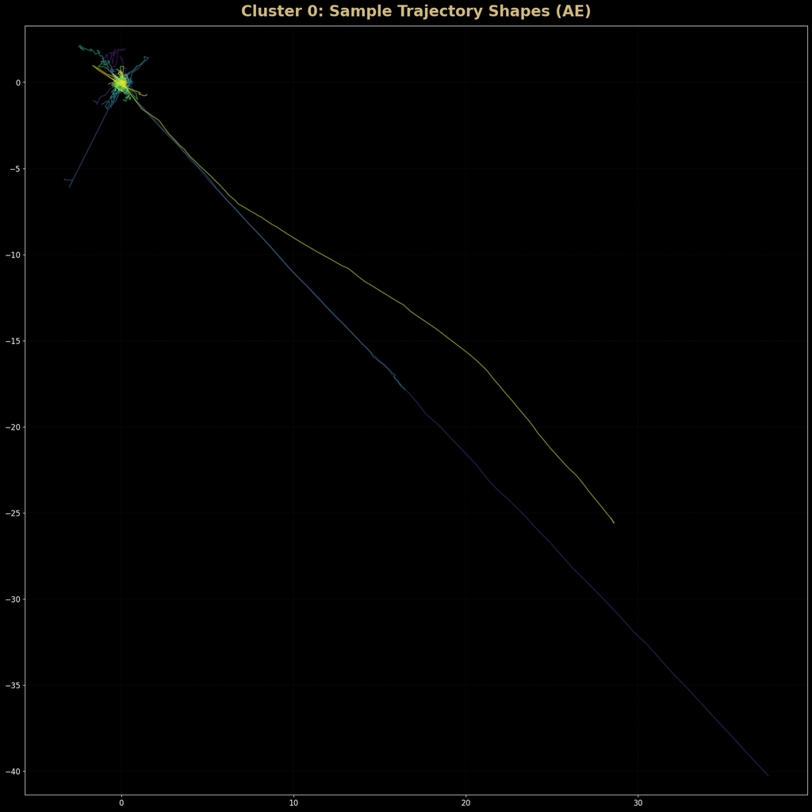

```
Figure saved to (Linux): /home/treinart/projects/lyft-unsupervised/artifacts/figures/20250917_220650_ae_cluster_0_sample_trajectories.png
Figure saved to (Win):   /mnt/c/Users/travi/Documents/Training/Colorado/MS-AI/CSCA 5632 Final Project/artifacts/figures/20250917_220650_ae_cluster_0_sample_trajectories.png
```

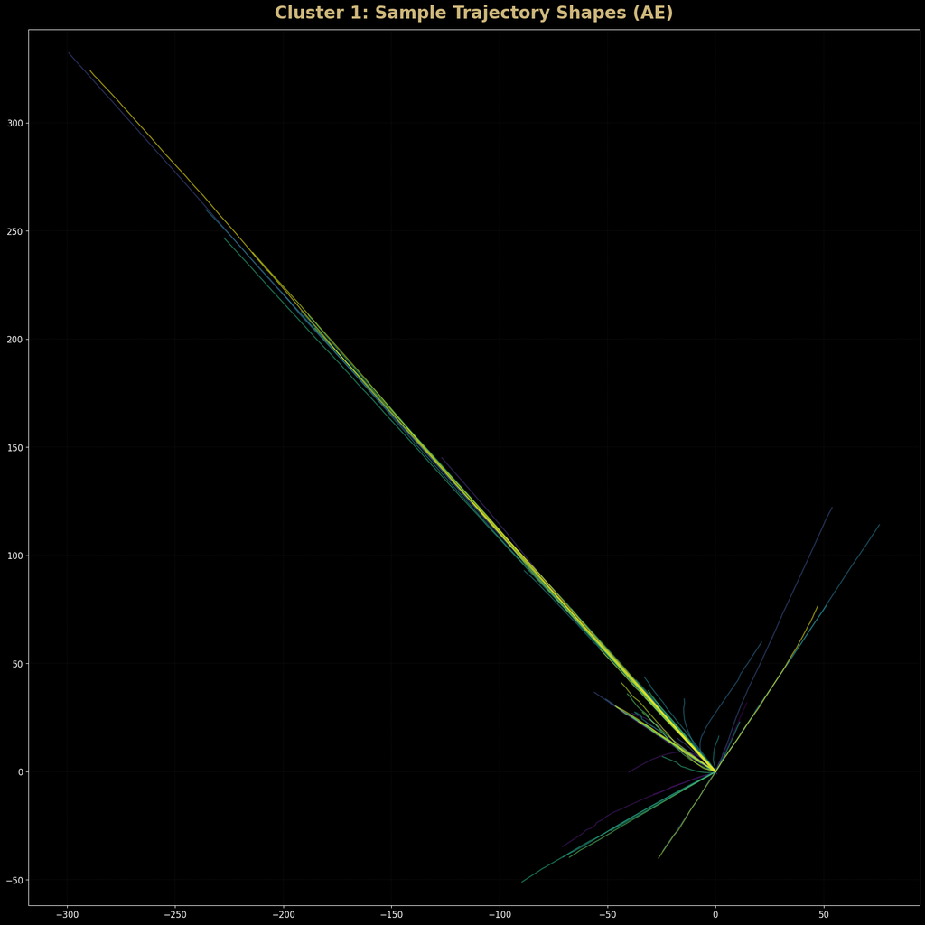

```
Figure saved to (Linux): /home/treinart/projects/lyft-unsupervised/artifacts/figures/20250917_220650_ae_cluster_1_sample_trajectories.png
Figure saved to (Win):   /mnt/c/Users/travi/Documents/Training/Colorado/MS-AI/CSCA 5632 Final Project/artifacts/figures/20250917_220650_ae_cluster_1_sample_trajectories.png
```

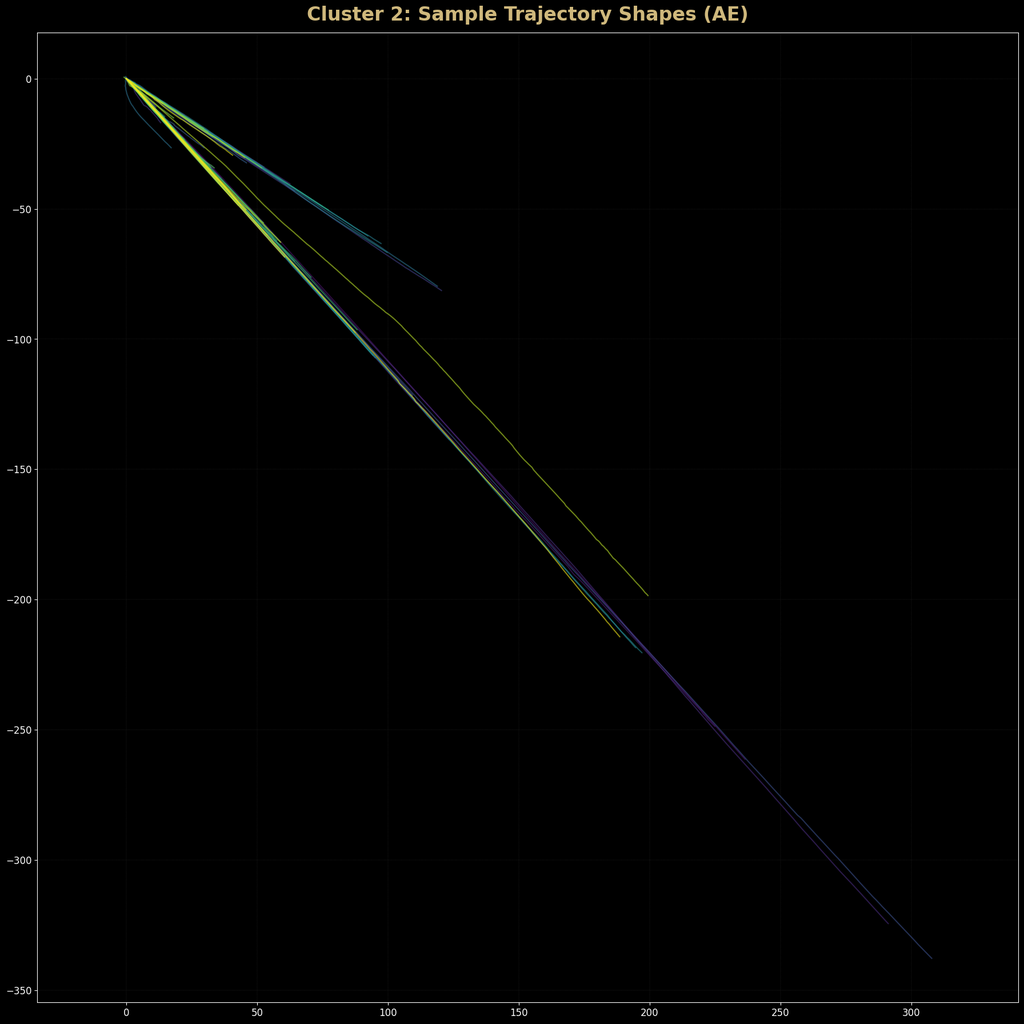

```
Figure saved to (Linux): /home/treinart/projects/lyft-unsupervised/artifacts/figures/20250917_220651_ae_cluster_2_sample_trajectories.png
Figure saved to (Win):   /mnt/c/Users/travi/Documents/Training/Colorado/MS-AI/CSCA 5632 Final Project/artifacts/figures/20250917_220651_ae_cluster_2_sample_trajectories.png
```

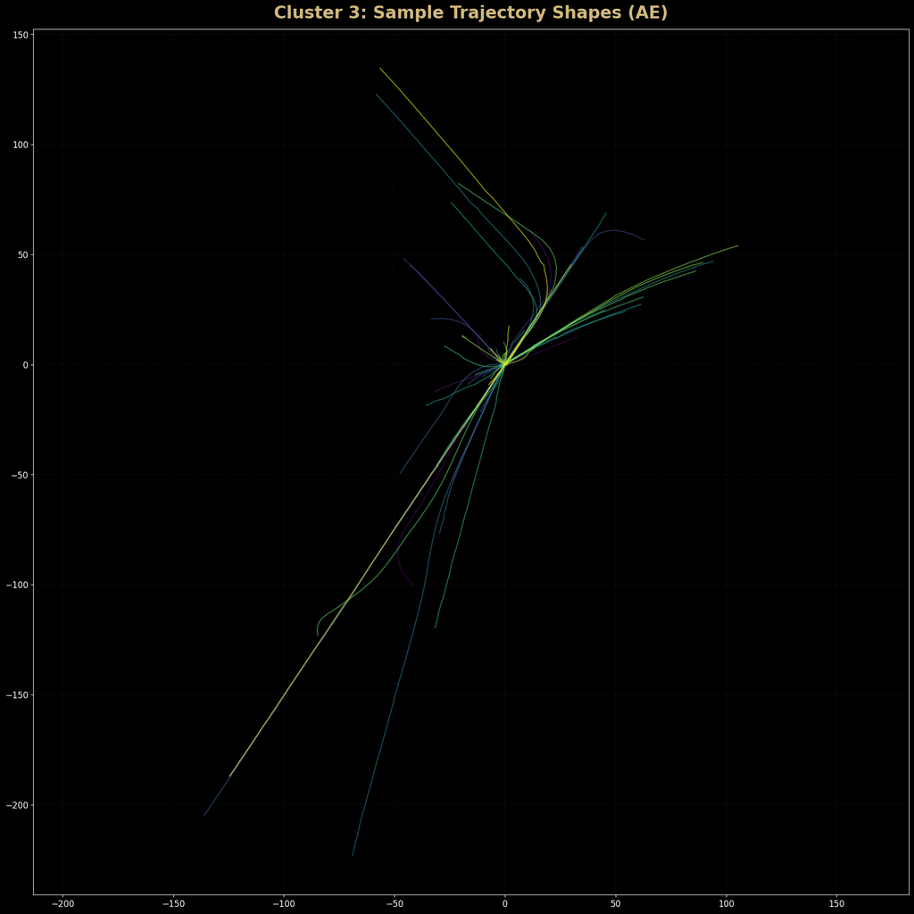

```
Figure saved to (Linux): /home/treinart/projects/lyft-unsupervised/artifacts/figures/20250917_220651_ae_cluster_3_sample_trajectories.png
Figure saved to (Win):   /mnt/c/Users/travi/Documents/Training/Colorado/MS-AI/CSCA 5632 Final Project/artifacts/figures/20250917_220651_ae_cluster_3_sample_trajectories.png
```

```python
# Prepare Data for Plotting
N_CLUSTERS_TO_SHOW = 8
N_SAMPLES_PER_CLUSTER = 75
cmap = plt.get_cmap("viridis")
top_clusters_ae = final_clusters_df_ae["cluster_id"].value_counts().nlargest(N_CLUSTERS_TO_SHOW).index.tolist()

# Create a Plot for Each Top Cluster
for cluster_id in sorted(top_clusters_ae):
    # Get and sample track identifiers for the current cluster
    track_ids_for_cluster = final_clusters_df_ae[final_clusters_df_ae["cluster_id"] == cluster_id]
    n_to_sample = min(N_SAMPLES_PER_CLUSTER, len(track_ids_for_cluster))
    sampled_tracks = track_ids_for_cluster.sample(n=n_to_sample, random_state=SEED)

    # Create the plot
    fig, ax = plt.subplots(figsize=(18, 18), facecolor="black")
    ax.set_facecolor("black")
    colors = cmap(np.linspace(0, 1, n_to_sample))

    # Plot each sampled trajectory, centered at (0,0)
    for i, (_, row) in enumerate(sampled_tracks.iterrows()):
        sid, tid = row["scene_id"], row["track_id"]
        track_data = agents_df_clean[(agents_df_clean["scene_id"] == sid) & (agents_df_clean["track_id"] == tid)].sort_values("frame_idx")
        x_norm = track_data["x"].to_numpy() - track_data["x"].iloc[0]
        y_norm = track_data["y"].to_numpy() - track_data["y"].iloc[0]
        ax.plot(x_norm, y_norm, color=colors[i], lw=1.5, alpha=0.6)

    # Style the plot
    ax.set_title(f"Cluster {cluster_id}: Sample Trajectory Shapes (AE)", fontsize=24, color="#CFB87C", fontweight="bold", pad=15)
    ax.tick_params(colors="white", labelsize=12)
    for spine in ax.spines.values(): spine.set_edgecolor("white")
    ax.set_aspect("equal", adjustable="datalim")
    ax.grid(color='gray', linestyle='--', linewidth=0.3, alpha=0.3)
    save_fig(fig, f"ae_cluster_{cluster_id}_sample_trajectories")
```

### **Observation: Clustering on the Learned Embeddings**

This section is the payoff from Section 7. After fixing the windowing and collapse issues, the embeddings behaved the way unsupervised features should: tight local neighborhoods, coherent global structure, and enough variance for separation without labels.

The initial health check passed. The matrix had shape **(9,944, 128)**, and **0** zero vectors were removed.

Three model families were evaluated: KMeans, GMM, and HDBSCAN. Metrics and stability drove the selection.

#### What the metrics said

- **KMeans sweep (k = 4 to 24).** Silhouette starts high and steps down as k grows (**0.935 → 0.814**). Calinski-Harabasz rises with more splits. Davies-Bouldin creeps upward. At **k = 4**, separation and compactness are strongest.
- **GMM sweep.** The **diag** covariance family wins on information criteria and stability. BIC favors **k = 20** for density fit, but silhouettes are lower than KMeans at small k. This reflects the tradeoff between fine-grained density modeling and interpretable groupings.
- **HDBSCAN.** Core-point silhouettes are excellent at moderate `min_cluster_size`, but noise rates climb quickly and the number of clusters drops. Signal is strong, practicality is limited for this dataset.
- **Stability (bootstrap ARI).** **KMeans k = 4** is very stable (**ARI ≈ 0.996**). The best GMM variant is also strong (**diag, k = 20, ARI ≈ 0.97**) but less interpretable.

These results select **KMeans with k = 4**. It provides the cleanest geometry, the highest useful silhouettes, and near-perfect stability.

#### What the clusters look like

Clusters were profiled with median kinematic features and validated against the sample trajectory shapes from 8.10.

- **Cluster 0 - idle and creep.** **stop_ratio ≈ 1.00**, **mean_speed ≈ 0.00**, short **duration ~5.3 s**, low straightness. Samples are tiny scribbles near the origin. Parked, staging, or inching segments.
- **Cluster 1 - fast and straight with light turning.** **mean_speed ≈ 12.06**, **p95 ≈ 13.89**, **straightness ~0.999**, **heading_change_rate ~0.49**. Long, mostly straight rays with a gentle bend.
- **Cluster 2 - fast and straighter.** Similar speeds (**mean ≈ 12.11**, **p95 ≈ 13.91**) with **lower heading_change_rate ~0.20**. Even more linear. Consistent lane-keeping runs.
- **Cluster 3 - moderate speed with frequent steering.** **mean_speed ≈ 5.33**, **p95 ≈ 9.12**, **heading_change_rate ~0.64**, longest **duration ~7.6 s**. Fans that bend and branch. Accel from stops, merges, or short maneuver segments.

These four groups align with the UMAP gradient from Section 7: stationary at one end, sustained motion at the other, with turning behavior splitting the two fast clusters.

#### Data notes

- Embeddings used: **9,944 × 128**, zero vectors dropped: **0**
- KMeans summary: silhouettes **0.935 → 0.814** as k grows; **k = 4** has the best composite score; **ARI ≈ 0.996**
- GMM summary: **diag** covariance wins BIC with **k = 20**; silhouettes below KMeans at low k; **ARI ≈ 0.97**
- HDBSCAN: strong core silhouettes but rising noise at larger `min_cluster_size`
- Final choice: **KMeans, k = 4**; artifacts saved for downstream steps

#### Runtime and optimization

[figure not shown]

**Conclusion**  
Section 8 confirms that the Section 7 embeddings carry clean structure. **KMeans with four clusters** is stable, interpretable, and consistent with the trajectory shapes. Speed and turning organize the space in a way that matches roadway behavior, giving a dependable behavior map for the rest of the pipeline.

## Section 9: Model Validation and Stress Testing

This section conducts a series of stress tests on the final model from Pipeline B. The goal is to determine if the clustering solution is stable, generalizable, and not just an artifact of a specific training run or hyperparameter choice. The analysis includes tests for stability against data resampling, sensitivity to hyperparameter changes, resilience to noise, and generalization to unseen data.

### Section Plan:

**Checkpoint & Loader:** Option to skip computation and load the latest cached artifacts.

**Setup:** Load the final data and define the label alignment helper function.

**Bootstrap Stability:** Test cluster stability by retraining the model on random subsets of the data.

**Hyperparameter Sensitivity:** Check how cluster assignments change with small adjustments to `k`.

**Stability Against Noise:** Measure the impact of adding noise and dropout to the embeddings.

**Generalization Test:** Perform a cross-validation test using disjoint sets of scenes.

**Final Scorecard:** Aggregate all test results into a final summary dashboard.

### 9.1 Checkpoint: Run Full Section or Load from Cache

This cell acts as a checkpoint for the validation section. The bootstrap and sensitivity tests involve retraining the model multiple times and can be slow. Set the flag below to control the behavior of this section.

**`True`:** Run the full suite of validation tests. This is required on the first run.

**`False`:** Skip the long computations and load the final stability dashboard from a previous run.

```python
# Set to True to run the time-consuming validation tests.
# Set to False to skip computation and load the final dashboard from a previous run.
RUN_VALIDATION_TESTS = True

if not RUN_VALIDATION_TESTS:
    print("--- Skipped: Loading final stability dashboard from cache ---")
    try:
        # Load the final stability dashboard, which is the key output of this section
        dashboard_df = pd.read_parquet(ARTIFACT_DIR / "pipeline_b_stability_dashboard.parquet")

        print(f"Loaded stability dashboard with {len(dashboard_df)} test results.")
        display(style_section_table(dashboard_df.round(4)))
        print("\n--- Successfully loaded artifacts. Ready to proceed to Section 10 ---")
    except FileNotFoundError:
        print("\n--- ERROR: No final artifacts found. Please set RUN_VALIDATION_TESTS to True and run the full section ---")
        RUN_VALIDATION_TESTS = True
else:
    print("--- RUN_VALIDATION_TESTS is True. Proceeding with full computation. ---")
```

```
--- RUN_VALIDATION_TESTS is True. Proceeding with full computation. ---
```

### 9.2 Setup and Helpers

This cell prepares the data for the validation tests. It loads the final embeddings and cluster labels from the previous sections and programmatically defines the champion model to be tested. It also defines a crucial `align_labels` utility, which uses the Hungarian algorithm to find the optimal mapping between two sets of cluster labels for accurate comparison.

```python
# This cell will only run if the full computation is enabled.
if RUN_VALIDATION_TESTS:
    # Load Necessary Artifacts from Previous Sections
    print("--- Loading Artifacts for Validation ---")
    track_embeddings_b = pd.read_parquet(ARTIFACT_DIR / "pipeline_b_track_embeddings.parquet")
    final_clusters_df_b = pd.read_parquet(ARTIFACT_DIR / "pipeline_b_cluster_assignments.parquet")
    with open(ARTIFACT_DIR / "pipeline_b_final_model_meta.json", 'r') as f:
        best_model_params_b = json.load(f)
    print("Loaded embeddings, cluster assignments, and model metadata for Pipeline B.")

    # Keep Variable Names Consistent
    Z_b = track_embeddings_b.filter(regex=r"^z\d+$").to_numpy(dtype=np.float32)
    y_ref = final_clusters_df_b["cluster_id"].astype(int).to_numpy()
    champion_params = best_model_params_b.copy()
    track_index = final_clusters_df_b[['scene_id', 'track_id']]

    # Define Helper Functions
    def fit_champion(Z_fit, cfg, seed):
        if cfg.get("model_type", cfg.get("model")) == "KMeans":
            model = KMeans(n_clusters=int(cfg["k"]), n_init="auto", random_state=seed)
        else: # GMM
            model = GaussianMixture(n_components=int(cfg["k"]), covariance_type=str(cfg["covariance_type"]), random_state=seed, reg_covar=1e-3)
        return model.fit(Z_fit)

    def pred_champion(model, Z_pred):
        return model.predict(Z_pred)

    def align_labels(y_true: np.ndarray, y_pred: np.ndarray) -> np.ndarray:
        common_mask = (y_true != -1) & (y_pred != -1)
        cm = confusion_matrix(y_true[common_mask], y_pred[common_mask])
        row_ind, col_ind = linear_sum_assignment(cm, maximize=True)
        mapping = {pred_idx: true_idx for true_idx, pred_idx in zip(row_ind, col_ind)}
        y_aligned = np.array([mapping.get(label, -1) for label in y_pred])
        return y_aligned

    # Perform a Sanity Check on Label Alignment
    print("\n--- Label Alignment Sanity Check ---")

    # Create a re-labeled version to test the alignment function
    rng = np.random.default_rng(SEED)
    unique_labels = np.unique(y_ref)
    shuffled_unique_labels = rng.permutation(unique_labels)
    relabel_map = {orig: new for orig, new in zip(unique_labels, shuffled_unique_labels)}
    y_relabeled = np.array([relabel_map[label] for label in y_ref])
    y_aligned_relabeled = align_labels(y_ref, y_relabeled)

    # Re-fit the champion model to create a stable reference partition for all subsequent tests
    model_full = fit_champion(Z_b, champion_params, SEED)
    y_full = pred_champion(model_full, Z_b)
    y_aligned_refit = align_labels(y_ref, y_full)

    # Display the results of the sanity checks
    display(style_section_table(pd.DataFrame([
        {"case": "Re-labeled vs. Original Reference", "ARI": ARI(y_ref, y_relabeled)},
        {"case": "Aligned Re-labeled vs. Reference", "ARI": ARI(y_ref, y_aligned_relabeled)},
        {"case": "Re-fitted vs. Original Reference", "ARI": ARI(y_ref, y_full)},
        {"case": "Aligned Re-fitted vs. Original Reference", "ARI": ARI(y_ref, y_aligned_refit)},
    ]).round(4)))

    # Confirm Final Setup
    print("\n--- Setup Complete ---")
    print(f"Tracks for analysis: {len(Z_b):,}")
    print(f"Champion Algorithm:  {champion_params.get('model_type', champion_params.get('model'))}")
    print(f"Clusters (k):        {int(champion_params['k'])}")
    if champion_params.get('model_type', champion_params.get('model')) == 'GMM':
        print(f"Covariance Type:     {champion_params['covariance_type']}")
else:
    print("--- Skipped: Loading from cache ---")
```

```
--- Loading Artifacts for Validation ---
Loaded embeddings, cluster assignments, and model metadata for Pipeline B.

--- Label Alignment Sanity Check ---
```

| case | ARI |
| --- | --- |
| Re-labeled vs. Original Reference | 1.000000 |
| Aligned Re-labeled vs. Reference | 1.000000 |
| Re-fitted vs. Original Reference | 1.000000 |
| Aligned Re-fitted vs. Original Reference | 1.000000 |

```
--- Setup Complete ---
Tracks for analysis: 9,944
Champion Algorithm:  KMeans
Clusters (k):        4
```

### **Observation: Label Alignment Sanity Check**

A table full of **1.00000** values is exactly what this cell should produce. It proves two things:

```
1: The label alignment utility correctly recognizes the same partition even when labels are permuted
2: The champion model is deterministic on the same data and seed.
```

**Result:**  
The measurement tools are calibrated, so later stability tests can be trusted.

### 9.3 Bootstrap Stability

This test assesses the stability of the clustering solution with respect to the data. The model is retrained multiple times on random bootstrap samples (80% of the data, sampled with replacement). The consistency of the resulting cluster assignments is then measured by calculating the pairwise Adjusted Rand Index (ARI) and Normalized Mutual Information (NMI) across all runs. A high average score indicates a stable model that finds similar structures even with variations in the training data.

```
--- Bootstrap Stability Summary ---
```

| metric | mean | std |
| --- | --- | --- |
| ARI | 0.993100 | 0.004000 |
| NMI | 0.980000 | 0.009900 |

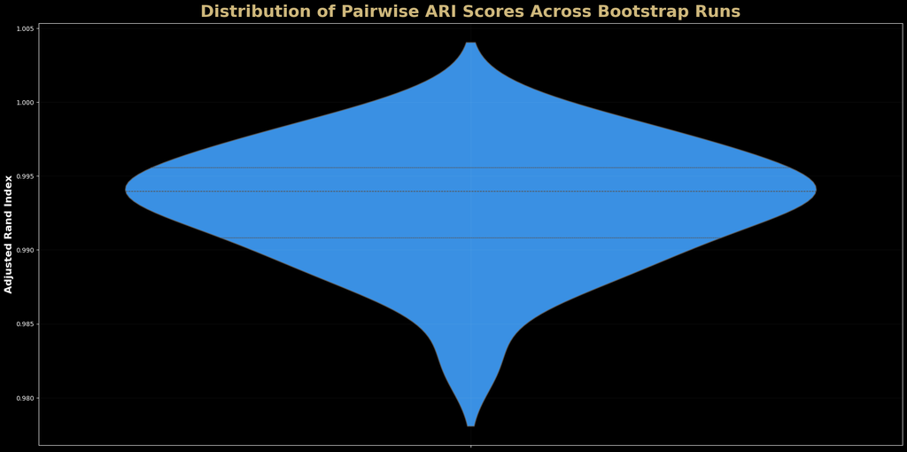

```
Figure saved to (Linux): /home/treinart/projects/lyft-unsupervised/artifacts/figures/20250917_220711_stability_bootstrap_ari_violin.png
Figure saved to (Win):   /mnt/c/Users/travi/Documents/Training/Colorado/MS-AI/CSCA 5632 Final Project/artifacts/figures/20250917_220711_stability_bootstrap_ari_violin.png
```

```python
# This cell will only run if the full computation is enabled.
if RUN_VALIDATION_TESTS:
    # Run Bootstrap Stability Test
    N_BOOTSTRAPS = 8
    FRAC = 0.80
    labels_runs = []
    for i in tqdm(range(N_BOOTSTRAPS), desc="Bootstrap Runs"):
        rng = np.random.default_rng(SEED + i)
        idx_sub = rng.choice(len(Z_b), size=int(len(Z_b) * FRAC), replace=True)
        Z_sub = Z_b[idx_sub]
        model_sub = fit_champion(Z_sub, champion_params, SEED + i)
        y_alt = pred_champion(model_sub, Z_b)
        y_alt_aligned = align_labels(y_ref, y_alt)
        labels_runs.append(y_alt_aligned)

    # Summarize and Visualize Results
    aris, nmis = [], []
    for i in range(len(labels_runs)):
        for j in range(i + 1, len(labels_runs)):
            aris.append(ARI(labels_runs[i], labels_runs[j]))
            nmis.append(NMI(labels_runs[i], labels_runs[j]))
    stability_summary = pd.DataFrame({"metric": ["ARI", "NMI"], "mean": [np.mean(aris), np.mean(nmis)], "std": [np.std(aris), np.std(nmis)]})
    print("--- Bootstrap Stability Summary ---")
    display(style_section_table(stability_summary.round(4)))

    # Create the Violin Plot
    fig, ax = plt.subplots(figsize=(20, 10), facecolor="black")
    ax.set_facecolor("black")
    sns.violinplot(data=pd.DataFrame({"ARI": aris}), y="ARI", color='dodgerblue', ax=ax, inner="quartile")
    ax.set_title("Distribution of Pairwise ARI Scores Across Bootstrap Runs", fontsize=26, color="#CFB87C", fontweight="bold", pad=10)
    ax.tick_params(colors="white")
    ax.set_ylabel("Adjusted Rand Index", fontsize=16, color="white", fontweight="bold")
    for sp in ax.spines.values():
        sp.set_edgecolor("white")
    ax.grid(color="white", alpha=0.08, linewidth=0.5)
    save_fig(fig, "stability_bootstrap_ari_violin")
else:
    print("--- Skipped: Loading from cache ---")
```

### 9.4 Hyperparameter Sensitivity

This test checks how sensitive the cluster assignments are to small changes in the number of clusters (`k`). The champion model is re-run with `k` values slightly above and below the chosen optimum. A high and stable ARI score across these runs indicates that the model's solution is stable and not an artifact of a single, specific hyperparameter choice.

```
--- Sensitivity to k Summary ---
```

| k | delta_k | ARI | NMI |
| --- | --- | --- | --- |
| 2 | -2 | 0.638500 | 0.588000 |
| 3 | -1 | 0.897900 | 0.844600 |
| 4 | 0 | 0.998100 | 0.992900 |
| 5 | 1 | 0.974500 | 0.938900 |
| 6 | 2 | 0.883900 | 0.841100 |

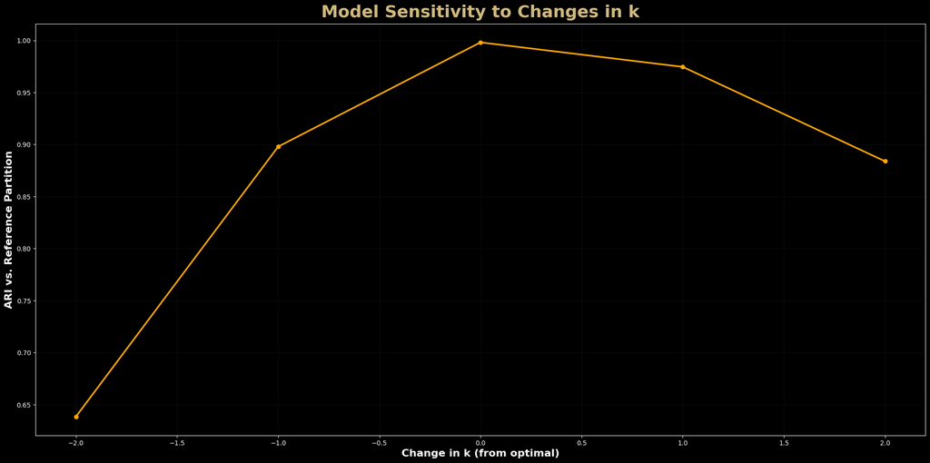

```
Figure saved to (Linux): /home/treinart/projects/lyft-unsupervised/artifacts/figures/20250917_220719_stability_sensitivity_delta_k.png
Figure saved to (Win):   /mnt/c/Users/travi/Documents/Training/Colorado/MS-AI/CSCA 5632 Final Project/artifacts/figures/20250917_220719_stability_sensitivity_delta_k.png
```

```python
# This cell will only run if the full computation is enabled.
if RUN_VALIDATION_TESTS:
    # Test Sensitivity to Changes in k
    k0 = int(champion_params["k"])
    K_LIST_SENSITIVITY = sorted({k for k in [k0-2, k0-1, k0, k0+1, k0+2] if k >= 2})
    sensitivity_rows = []
    for k in tqdm(K_LIST_SENSITIVITY, desc="Testing Sensitivity to k"):
        cfg = champion_params.copy()
        cfg["k"] = k
        model_k = fit_champion(Z_b, cfg, SEED + k)
        y_alt = pred_champion(model_k, Z_b)
        y_alt_aligned = align_labels(y_ref, y_alt)
        ari = ARI(y_ref, y_alt_aligned)
        nmi = NMI(y_ref, y_alt_aligned)
        sensitivity_rows.append({"k": k, "delta_k": k - k0, "ARI": ari, "NMI": nmi})
    sensitivity_df = pd.DataFrame(sensitivity_rows)
    print("--- Sensitivity to k Summary ---")
    display(style_section_table(sensitivity_df.round(4)))

    # Visualize Results
    fig, ax = plt.subplots(figsize=(20, 10), facecolor="black")
    ax.set_facecolor("black")
    ax.plot(sensitivity_df["delta_k"], sensitivity_df["ARI"], marker="o", lw=2.5, color='orange')
    ax.set_title("Model Sensitivity to Changes in k", fontsize=26, color="#CFB87C", fontweight="bold", pad=10)
    ax.set_xlabel("Change in k (from optimal)", fontsize=16, color="white", fontweight="bold")
    ax.set_ylabel("ARI vs. Reference Partition", fontsize=16, color="white", fontweight="bold")
    ax.tick_params(colors="white")
    for sp in ax.spines.values():
        sp.set_edgecolor("white")
    ax.grid(color="white", alpha=0.08, linewidth=0.5)
    save_fig(fig, "stability_sensitivity_delta_k")
else:
    print("--- Skipped: Loading from cache ---")
```

### 9.5 Stability Against Noise and Data Loss

A model's value depends on its performance with imperfect, real-world data. This analysis tests the champion model's stability against two common types of data degradation. First, we add Gaussian noise to the embeddings to simulate minor representation errors. Second, we apply latent dropout, setting random feature dimensions to zero to simulate information loss. A stable model should maintain high-quality cluster assignments even with these induced imperfections.

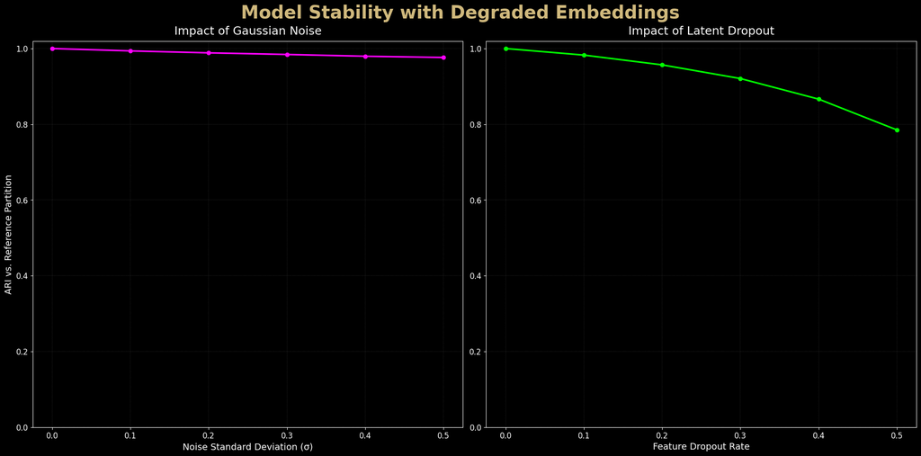

```
Figure saved to (Linux): /home/treinart/projects/lyft-unsupervised/artifacts/figures/20250917_220724_stability_noise_dropout.png
Figure saved to (Win):   /mnt/c/Users/travi/Documents/Training/Colorado/MS-AI/CSCA 5632 Final Project/artifacts/figures/20250917_220724_stability_noise_dropout.png
```

```python
# This cell will only run if the full computation is enabled.
if RUN_VALIDATION_TESTS:

    # Test Stability with Gaussian Noise
    SIGMAS = [0.0, 0.1, 0.2, 0.3, 0.4, 0.5]
    noise_rows = []
    for sigma in tqdm(SIGMAS, desc="Testing Gaussian Noise"):
        # Explicitly create the noisy data for this iteration
        if sigma == 0:
            Z_noisy = Z_b
        else:
            rng = np.random.default_rng(SEED + int(sigma * 100))
            noise = rng.normal(0, sigma, size=Z_b.shape)
            Z_noisy = (Z_b + noise).astype(np.float32)

        # Predict on the noisy data and align the labels
        y_pred_noisy = model_full.predict(Z_noisy)
        y_aligned_noisy = align_labels(y_full, y_pred_noisy)

        noise_rows.append({"sigma": sigma, "ARI": ARI(y_full, y_aligned_noisy), "NMI": NMI(y_full, y_aligned_noisy)})
    noise_df = pd.DataFrame(noise_rows)

    # Test Stability with Latent Dropout
    DROPOUT_RATES = [0.0, 0.1, 0.2, 0.3, 0.4, 0.5]
    dropout_rows = []
    for rate in tqdm(DROPOUT_RATES, desc="Testing Latent Dropout"):
        # Explicitly create the degraded data for this iteration
        Z_dropout = Z_b.copy().astype(np.float32)
        if rate > 0:
            rng = np.random.default_rng(SEED + int(rate * 10))
            n_features_to_drop = int(Z_b.shape[1] * rate)
            if n_features_to_drop > 0:
                for i in range(len(Z_dropout)):
                    cols_to_drop = rng.choice(Z_b.shape[1], n_features_to_drop, replace=False)
                    Z_dropout[i, cols_to_drop] = 0.0

        # Predict on the degraded data and align the labels
        y_pred_dropout = model_full.predict(Z_dropout)
        y_aligned_dropout = align_labels(y_full, y_pred_dropout)

        dropout_rows.append({"drop_rate": rate, "ARI": ARI(y_full, y_aligned_dropout), "NMI": NMI(y_full, y_aligned_dropout)})
    dropout_df = pd.DataFrame(dropout_rows)

    # Visualize Results
    fig, (ax1, ax2) = plt.subplots(1, 2, figsize=(20, 10), facecolor="black")
    fig.patch.set_facecolor("black")
    fig.suptitle("Model Stability with Degraded Embeddings", fontsize=28, color="#CFB87C", fontweight="bold")

    # Plot 1: Gaussian Noise
    ax1.plot(noise_df["sigma"], noise_df["ARI"], marker="o", lw=2.5, color='magenta')
    ax1.set_title("Impact of Gaussian Noise", fontsize=18, color="#F8F8F8", pad=10)
    ax1.set_xlabel("Noise Standard Deviation (σ)", fontsize=14, color="white")
    ax1.set_ylabel("ARI vs. Reference Partition", fontsize=14, color="white")

    # Plot 2: Latent Dropout
    ax2.plot(dropout_df["drop_rate"], dropout_df["ARI"], marker="o", lw=2.5, color='lime')
    ax2.set_title("Impact of Latent Dropout", fontsize=18, color="#F8F8F8", pad=10)
    ax2.set_xlabel("Feature Dropout Rate", fontsize=14, color="white")

    # Style both subplots
    for ax in [ax1, ax2]:
        ax.set_facecolor("black"); ax.tick_params(colors="white", labelsize=12); ax.set_ylim(bottom=0, top=1.02)
        for spine in ax.spines.values(): spine.set_edgecolor("white")
        ax.grid(color='gray', linestyle='--', linewidth=0.3, alpha=0.5)

    save_fig(fig, "stability_noise_dropout")
else:
    print("--- Skipped: Loading from cache ---")
```

### 9.6 Generalization Test

This is a strong test of the model's ability to generalize. The data is split into two halves (A and B) based on scene ID. A model is trained on split A and used to predict clusters for split B, and vice-versa. A high ARI score shows that the learned cluster definitions are not specific to the training data and can be successfully applied to new, unseen scenes.

```python
# This cell will only run if the full computation is enabled.
if RUN_VALIDATION_TESTS:
    # Run Cross-Split Generalization Test
    scenes = track_index["scene_id"].to_numpy()
    mask_A = (scenes % 2 == 0)
    mask_B = ~mask_A
    Z_A, Z_B = Z_b[mask_A], Z_b[mask_B]
    y_ref_A, y_ref_B = y_ref[mask_A], y_ref[mask_B]

    # Train on split A, predict on split B
    print("\n--- Training on Split A, predicting on Split B ---")
    model_A = fit_champion(Z_A, champion_params, SEED)
    y_pred_B = pred_champion(model_A, Z_B)
    y_pred_B_aligned = align_labels(y_ref_B, y_pred_B)
    ari_A_to_B = ARI(y_ref_B, y_pred_B_aligned)
    nmi_A_to_B = NMI(y_ref_B, y_pred_B_aligned)

    # Train on split B, predict on split A
    print("\n--- Training on Split B, predicting on Split A ---")
    model_B = fit_champion(Z_B, champion_params, SEED)
    y_pred_A = pred_champion(model_B, Z_A)
    y_pred_A_aligned = align_labels(y_ref_A, y_pred_A)
    ari_B_to_A = ARI(y_ref_A, y_pred_A_aligned)
    nmi_B_to_A = NMI(y_ref_A, y_pred_A_aligned)

    # Display Results
    cross_split_df = pd.DataFrame([
        {"Train Split": "A", "Test Split": "B", "Tracks": len(Z_B), "ARI": ari_A_to_B, "NMI": nmi_A_to_B},
        {"Train Split": "B", "Test Split": "A", "Tracks": len(Z_A), "ARI": ari_B_to_A, "NMI": nmi_B_to_A},
    ])
    print("\n--- Cross-Split Generalization Summary ---")
    display(style_section_table(cross_split_df.round(4)))
else:
    print("--- Skipped: Loading from cache ---")
```

```
--- Training on Split A, predicting on Split B ---

--- Training on Split B, predicting on Split A ---

--- Cross-Split Generalization Summary ---
```

| Train Split | Test Split | Tracks | ARI | NMI |
| --- | --- | --- | --- | --- |
| A | B | 4128 | 0.980700 | 0.952700 |
| B | A | 5816 | 0.976300 | 0.940500 |

### 9.7 Final Stability Scorecard

This final dashboard aggregates the results from all stability and sensitivity tests into a single table. A composite score is calculated to provide a holistic measure of the champion model's quality, combining its stability, sensitivity, and generalization performance.

```python
# This cell will only run if the full computation is enabled.
if RUN_VALIDATION_TESTS:
    # Aggregate All Test Results into a Single Dashboard
    dashboard_rows = []
    dashboard_rows.append({"test": "Bootstrap Pairwise", "ARI": np.mean(aris), "NMI": np.mean(nmis)})
    for _, row in sensitivity_df.iterrows(): dashboard_rows.append({"test": f"Sensitivity (k={int(row.k)})", "ARI": row.ARI, "NMI": row.NMI})
    for _, row in noise_df.iterrows(): dashboard_rows.append({"test": f"Noise (σ={row.sigma:.2f})", "ARI": row.ARI, "NMI": row.NMI})
    for _, row in dropout_df.iterrows(): dashboard_rows.append({"test": f"Dropout (rate={row.drop_rate:.1f})", "ARI": row.ARI, "NMI": row.NMI})
    for _, row in cross_split_df.iterrows(): dashboard_rows.append({"test": f"Generalization ({row['Train Split']}→{row['Test Split']})", "ARI": row.ARI, "NMI": row.NMI})
    dashboard_df = pd.DataFrame(dashboard_rows)

    # Calculate a Composite Score
    def _z(a):
        a = np.asarray(a, dtype=float)
        return (a - np.nanmean(a)) / (np.nanstd(a) + 1e-9)
    dashboard_df["score"] = _z(dashboard_df["ARI"]) + _z(dashboard_df["NMI"])

    # Display the Final Dashboard
    print("--- Final Stability Test Dashboard ---")
    display(style_section_table(dashboard_df.round(4)))

    # Save the Dashboard for Reference
    print("\n--- Saving final stability dashboard for later use ---")
    dashboard_df.to_parquet(ARTIFACT_DIR / "pipeline_b_stability_dashboard.parquet", index=False)
    print(f"Saved to: {ARTIFACT_DIR / 'pipeline_b_stability_dashboard.parquet'}")
    _save_df(dashboard_df, "final_stability_dashboard_timestamped") # Also save a timestamped version for cache
else:
    print("--- Skipped: Loading from cache ---")
```

```
--- Final Stability Test Dashboard ---
```

| test | ARI | NMI | score |
| --- | --- | --- | --- |
| Bootstrap Pairwise | 0.993100 | 0.980000 | 1.380700 |
| Sensitivity (k=2) | 0.638500 | 0.588000 | -6.260800 |
| Sensitivity (k=3) | 0.897900 | 0.844600 | -0.949300 |
| Sensitivity (k=4) | 0.998100 | 0.992900 | 1.555800 |
| Sensitivity (k=5) | 0.974500 | 0.938900 | 0.790600 |
| Sensitivity (k=6) | 0.883900 | 0.841100 | -1.140900 |
| Noise (σ=0.00) | 1.000000 | 1.000000 | 1.643400 |
| Noise (σ=0.10) | 0.993700 | 0.981400 | 1.400600 |
| Noise (σ=0.20) | 0.988600 | 0.963200 | 1.174300 |
| Noise (σ=0.30) | 0.984300 | 0.956500 | 1.063700 |
| Noise (σ=0.40) | 0.979600 | 0.938600 | 0.845800 |
| Noise (σ=0.50) | 0.976400 | 0.929100 | 0.721500 |
| Dropout (rate=0.0) | 1.000000 | 1.000000 | 1.643400 |
| Dropout (rate=0.1) | 0.982600 | 0.944000 | 0.929900 |
| Dropout (rate=0.2) | 0.956800 | 0.886400 | 0.104800 |
| Dropout (rate=0.3) | 0.920700 | 0.818300 | -0.933400 |
| Dropout (rate=0.4) | 0.866400 | 0.757100 | -2.114900 |
| Dropout (rate=0.5) | 0.785100 | 0.688600 | -3.669500 |
| Generalization (A→B) | 0.980700 | 0.952700 | 0.988600 |
| Generalization (B→A) | 0.976300 | 0.940500 | 0.825700 |

```
--- Saving final stability dashboard for later use ---
Saved to: /home/treinart/projects/lyft-unsupervised/artifacts/pipeline_b_stability_dashboard.parquet
```

### **Observation: Validation and Stability**

Section 9 asks if the selected partition is real, repeatable, and portable. The evidence says yes.

**Calibration**  
The label-alignment sanity check returns 1.00000 across the board, which confirms two things: the alignment utility is correct, and the champion model is deterministic on the same data and seed. Measurement tools are trustworthy.

- ARI mean 0.993, std 0.004
- NMI mean 0.980, std 0.0099  
  This is the footprint of a stable solution rather than a one-off clustering.

**Sensitivity to k**  
The landscape around the winner is well behaved.

- k = 4 matches itself, ARI ≈ 0.998, NMI ≈ 0.993
- k = 3 and k = 5 remain close (ARI ~ 0.90 and 0.97) which hints at mild substructure without overturning the 4-cluster view
- k = 2 collapses distinct behaviors, ARI ~ 0.64  
  Conclusion: four clusters is a defensible default with graceful degradation on either side.

**Reliability under embedding drift**

- Gaussian noise up to σ = 0.5 keeps ARI ≥ 0.976 and NMI ≥ 0.929, so small geometric perturbations do not matter.
- Latent feature dropout is tougher. Light dropout is fine, but heavy dropout shifts assignments: ARI ~ 0.92 at 0.30, ~ 0.87 at 0.40, ~ 0.79 at 0.50. This identifies the failure mode to watch.  
  Assignments remain stable under moderate noise and only shift with heavy feature dropout.

**Cross-split generalization**  
Train on one half, predict on the other, then swap. Both directions land near-perfect agreement.

- A → B: ARI 0.9807, NMI 0.9527
- B → A: ARI 0.9763, NMI 0.9405  
  The partition transfers cleanly to unseen tracks.

**Roll-Up**  
The dashboard mirrors the individual tests: high bootstrap stability, strong cross-split transfer, smooth response to k near 4, and predictable degradation only under severe latent dropout.

**Conclusion**  
The champion KMeans model with k = 4 is stable, reproducible, and ready for downstream use. Keep k = 5 as an exploratory cut when finer groupings are useful, monitor for conditions that mimic latent dropout, and preserve seeds plus label maps to maintain exact reproducibility.

## Section 10: Interpretation - Scenario Archetypes

With a stable clustering solution defined, the final step is to interpret what these abstract groups represent. This section translates the discovered clusters into human-understandable "scenario archetypes" by visualizing their defining characteristics. The goal is to move beyond metrics and build a qualitative understanding of the different behaviors present in the data.

### Section Plan:

**Checkpoint & Loader:** Option to skip computation and load the final cached artifacts.

**Behavior Signatures:** Engineer per-track kinematic features to quantify motion.

**Cluster Profiles:** Aggregate track signatures to create a high-level summary for each cluster.

**Exemplar Identification:** Find the most representative track ("centroid exemplar") for each cluster.

**Scenario Cards:** Create a detailed, multi-panel visualization for each cluster archetype.

**Scenario Gallery:** Present a high-level gallery of all discovered archetypes.

**Deep Dive Animation:** Render an animated replay of a representative scenario.

### 10.1 Checkpoint: Run Full Section or Load from Cache

This cell acts as a checkpoint for the interpretation section. Generating the behavior signatures and rendering the scenario cards can be time-consuming. Set the flag below to control the behavior of this section.

**`True`:** Run the full interpretation pipeline. This is required on the first run.

**`False`:** Skip the long computations and load the final cluster summary from a previous run.

```python
# Set to True to run the time-consuming interpretation and visualization pipeline.
# Set to False to skip computation and load the final cluster summary.
RUN_INTERPRETATION = True

if not RUN_INTERPRETATION:
    print("--- Skipped: Loading final cluster summary from cache ---")
    try:
        # Load the final cluster summary, which is the key output of this section
        cluster_summary = pd.read_parquet(ARTIFACT_DIR / "pipeline_b_cluster_summary.parquet")

        print(f"Loaded cluster summary for {len(cluster_summary)} clusters.")
        print("\n--- Successfully loaded artifacts. Ready to proceed to Section 11 ---")
    except FileNotFoundError:
        print("\n--- ERROR: No final artifacts found. Please set RUN_INTERPRETATION to True and run the full section ---")
        RUN_INTERPRETATION = True
else:
    print("--- RUN_INTERPRETATION is True. Proceeding with full computation. ---")
```

```
--- RUN_INTERPRETATION is True. Proceeding with full computation. ---
```

### 10.2 Behavior Signature Engineering

To interpret the clusters, each track must first be described by a set of quantitative metrics. This cell calculates a "behavior signature" for every track in the dataset, capturing key kinematic properties like speed, acceleration, and turning rate. These signatures form the foundation for profiling and comparing the discovered clusters.

```python
# This cell will only run if the full computation is enabled.
if RUN_INTERPRETATION:
    # Define a function to calculate kinematic features for a single track
    def _track_signature(g, stall_thr=0.5): # Use 0.5 for consistency
        g = g.sort_values('frame_idx')
        vx, vy = g['vx'].to_numpy(float), g['vy'].to_numpy(float)

        # Calculate speed, heading, turn rate, and acceleration
        speed = (vx**2 + vy**2)**0.5
        heading = np.unwrap(np.arctan2(vy, vx)) # Unwrap for correct stats
        turn_rate = np.abs(np.diff(heading)) / DT if len(heading) > 1 else np.array([])
        accel = np.diff(speed) / DT if len(speed) > 1 else np.array([])

        def _percentile(x, q): return float(np.nanpercentile(x, q)) if len(x) > 0 else np.nan

        # Return a dictionary of summary statistics
        return {
            'n_frames': int(len(g)), 'speed_p50': _percentile(speed, 50),
            'speed_p90': _percentile(speed, 90), 'speed_max': np.nanmax(speed) if len(speed) > 0 else np.nan,
            'speed_std': float(np.nanstd(speed)) if len(speed) > 0 else np.nan,
            'acc_p90': _percentile(np.abs(accel), 90), 'turn_p90': _percentile(turn_rate, 90),
            'heading_std': float(np.nanstd(heading)), # Now correct due to unwrap
            'stationarity': float(np.mean(speed < stall_thr)),
        }

    # Calculate signatures for all tracks
    groups = agents_df_clean.groupby(['scene_id','track_id'], sort=False)
    rows = []
    for (sid, tid), g in tqdm(groups, desc="Behavior Signatures", unit="track"):
        rows.append({'scene_id': sid, 'track_id': tid, **_track_signature(g)})
    sig_df = pd.DataFrame(rows)

    # Attach the champion cluster labels
    sig_df = sig_df.merge(final_clusters_df_ae, on=['scene_id','track_id'], how='left')

    # Display a formatted preview
    pretty = sig_df.head(10).copy()
    metrics_to_format = [c for c in pretty.columns if c not in ['scene_id', 'track_id', 'n_frames', 'cluster_id']]
    for col in metrics_to_format: pretty[col] = pretty[col].apply(lambda x: f"{x:.3f}" if pd.notna(x) else "---")
    print("--- Per-Track Behavior Signatures ---")
    display(style_section_table(pretty))
else:
    print("--- Skipped: Loading from cache ---")
```

```
--- Per-Track Behavior Signatures ---
```

| scene_id | track_id | n_frames | speed_p50 | speed_p90 | speed_max | speed_std | acc_p90 | turn_p90 | heading_std | stationarity | cluster_id |
| --- | --- | --- | --- | --- | --- | --- | --- | --- | --- | --- | --- |
| 108 | 1 | 67 | 0.000 | 0.000 | 0.741 | 0.105 | 0.000 | 0.000 | 0.368 | 0.985 | 0.000000 |
| 108 | 2 | 248 | 0.000 | 0.000 | 0.290 | 0.021 | 0.000 | 0.000 | 0.217 | 1.000 | 0.000000 |
| 108 | 3 | 56 | 0.000 | 0.000 | 0.471 | 0.075 | 0.000 | 0.000 | 0.253 | 1.000 | 0.000000 |
| 108 | 4 | 87 | 0.000 | 0.000 | 0.653 | 0.083 | 0.000 | 0.000 | 0.065 | 0.989 | 0.000000 |
| 108 | 5 | 248 | 0.050 | 6.842 | 7.618 | 2.962 | 1.680 | 14.259 | 2.693 | 0.544 | 0.000000 |
| 108 | 6 | 60 | 0.000 | 0.000 | 0.198 | 0.032 | 0.000 | 0.000 | 1.215 | 1.000 | 0.000000 |
| 108 | 7 | 248 | 0.000 | 0.084 | 0.378 | 0.057 | 0.166 | 1.780 | 1.283 | 1.000 | 0.000000 |
| 108 | 8 | 248 | 0.590 | 6.358 | 8.125 | 2.605 | 1.513 | 7.379 | 1.938 | 0.492 | 0.000000 |
| 108 | 9 | 248 | 0.013 | 0.161 | 1.622 | 0.141 | 0.620 | 22.847 | 3.976 | 0.992 | 0.000000 |
| 108 | 10 | 1 | 0.000 | 0.000 | 0.000 | 0.000 | --- | --- | 0.000 | 1.000 | nan |

### 10.3 Cluster Profile Summary

With signatures calculated for every track, the next step is to aggregate them. This cell groups the tracks by their assigned cluster ID and computes the median value for each kinematic feature. The result is a high-level summary table that provides a distinct, quantitative profile for each cluster, highlighting the central tendency of its behavior.

```python
# This cell will only run if the full computation is enabled.
if RUN_INTERPRETATION:
    # Define the metrics to be aggregated
    metrics = ['speed_p50', 'speed_p90', 'speed_max', 'speed_std', 'acc_p90', 'turn_p90', 'heading_std', 'stationarity']

    # Group by cluster and calculate median statistics
    cluster_summary = sig_df.groupby('cluster_id')[metrics].median()
    cluster_summary = cluster_summary.rename(columns={m: f"med_{m}" for m in metrics})
    counts = sig_df['cluster_id'].value_counts().rename('n_tracks')
    pcts = sig_df['cluster_id'].value_counts(normalize=True).rename('pct') * 100
    cluster_summary = cluster_summary.join(counts).join(pcts).reset_index()

    # Create and display a formatted preview
    pretty_summary = cluster_summary.sort_values('n_tracks', ascending=False).copy()
    for col in [c for c in pretty_summary.columns if c.startswith('med_')]: pretty_summary[col] = pretty_summary[col].apply(lambda x: f"{x:.3f}" if pd.notna(x) else "---")
    pretty_summary['pct'] = pretty_summary['pct'].apply(lambda x: f"{x:.2f}%")
    print("--- Cluster Profile Summary ---")
    display(style_section_table(pretty_summary))

    # Save the final summary table for later use
    print("\n--- Saving final cluster summary for later use ---")
    cluster_summary.to_parquet(ARTIFACT_DIR / "pipeline_b_cluster_summary.parquet", index=False)
    print(f"Saved to: {ARTIFACT_DIR / 'pipeline_b_cluster_summary.parquet'}")
else:
    print("--- Skipped: Loading from cache ---")
```

```
--- Cluster Profile Summary ---
```

| cluster_id | med_speed_p50 | med_speed_p90 | med_speed_max | med_speed_std | med_acc_p90 | med_turn_p90 | med_heading_std | med_stationarity | n_tracks | pct |
| --- | --- | --- | --- | --- | --- | --- | --- | --- | --- | --- |
| 0.000000 | 0.000 | 0.000 | 0.137 | 0.023 | 0.000 | 0.000 | 0.161 | 1.000 | 8964 | 90.14% |
| 1.000000 | 12.803 | 13.745 | 14.168 | 2.323 | 1.945 | 0.115 | 0.393 | 0.026 | 415 | 4.17% |
| 2.000000 | 12.123 | 13.330 | 13.789 | 2.227 | 1.681 | 0.120 | 0.131 | 0.027 | 330 | 3.32% |
| 3.000000 | 4.973 | 8.155 | 8.560 | 1.706 | 2.235 | 0.560 | 0.403 | 0.038 | 235 | 2.36% |

```
--- Saving final cluster summary for later use ---
Saved to: /home/treinart/projects/lyft-unsupervised/artifacts/pipeline_b_cluster_summary.parquet
```

### 10.4 Centroid Exemplar Identification

While median statistics are useful, they do not capture the nuance of a cluster. To provide a more concrete visual interpretation, this cell identifies the most representative track for each cluster. This "centroid exemplar" is the track closest to the cluster's center in the high-dimensional latent space. It serves as the primary visual example in the scenario cards that follow.

```python
# This cell will only run if the full computation is enabled.
if RUN_INTERPRETATION:
    # Align embeddings with their final cluster labels
    z_cols = [c for c in track_embeddings_df.columns if c.startswith('z')]
    cards_df = track_embeddings_df[["scene_id","track_id"] + z_cols].merge(final_clusters_df_ae, on=["scene_id","track_id"], how="inner").dropna(subset=["cluster_id"]).reset_index(drop=True)
    Z_cards = cards_df[z_cols].to_numpy(dtype=np.float32)
    y_cards = cards_df["cluster_id"].astype(int).to_numpy()
    key_cards = cards_df[["scene_id","track_id"]].copy()

    # Find the centroid exemplar and a set of samples for each cluster
    centroid_exemplars = {}
    sample_exemplars = {}
    for cid in tqdm(np.unique(y_cards), desc="Finding Exemplars", unit="cluster"):
        idx = np.where(y_cards == cid)[0]
        if len(idx) == 0: continue

        # Calculate distances to the latent space centroid
        Zc = Z_cards[idx]
        distances = np.linalg.norm(Zc - Zc.mean(axis=0, keepdims=True), axis=1)
        order = np.argsort(distances)

        # Store the original DataFrame indices
        centroid_exemplars[cid] = idx[order[0]]
        sample_exemplars[cid] = idx[order[:20]]

    # Display a preview of the identified exemplars
    rows = [{'Cluster': int(cid), **key_cards.iloc[idx].to_dict()} for cid, idx in sorted(centroid_exemplars.items())]
    exemplar_preview = pd.DataFrame(rows)
    print("--- Centroid Exemplar Tracks (Per Cluster) ---")
    display(style_section_table(exemplar_preview))
else:
    print("--- Skipped: Loading from cache ---")
```

```
--- Centroid Exemplar Tracks (Per Cluster) ---
```

| Cluster | scene_id | track_id |
| --- | --- | --- |
| 0 | 4214 | 1578 |
| 1 | 5803 | 2 |
| 2 | 15502 | 9 |
| 3 | 10600 | 78 |

### 10.5 Scenario Cards

This is the centerpiece of the interpretation stage. The following code generates a "scenario card" for each cluster. Each card is a rich, multi-panel visualization that synthesizes information from different stages of the analysis. It provides a view of each behavior archetype by combining a quantitative signature (radar chart), a qualitative shape of motion (trajectory plots), and a contextual view of the latent space (UMAP plot).

```
--- Building fast trajectory lookup dictionary ---
```

[output not shown]

```
Epochs completed:   0%|            0/500 [00:00]
```

[output not shown]

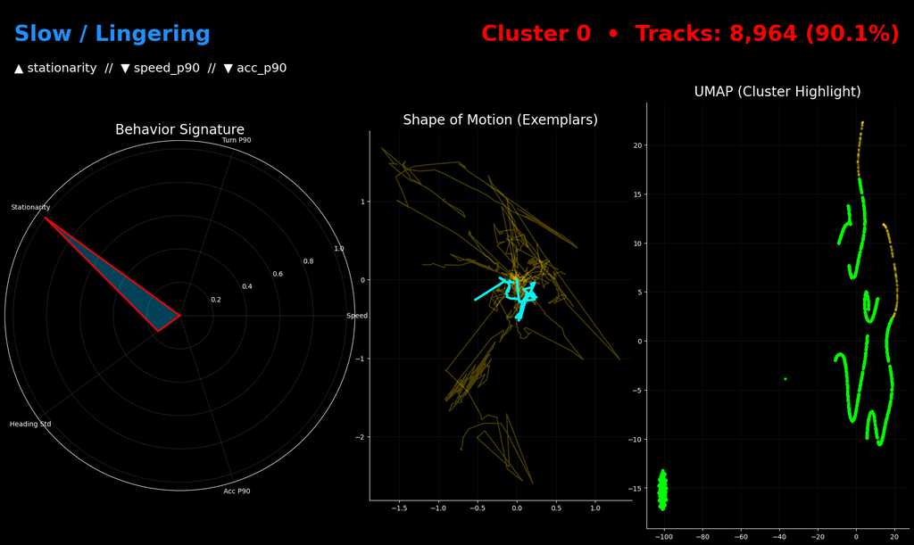

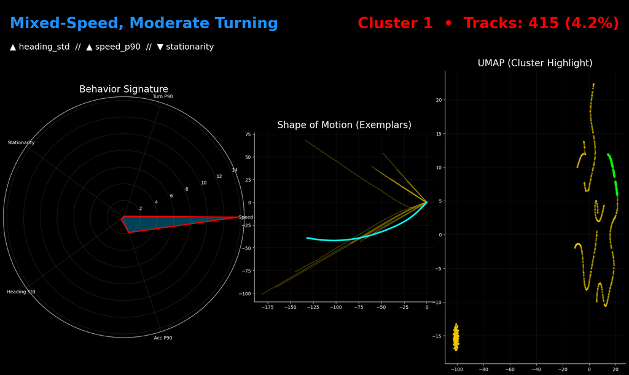

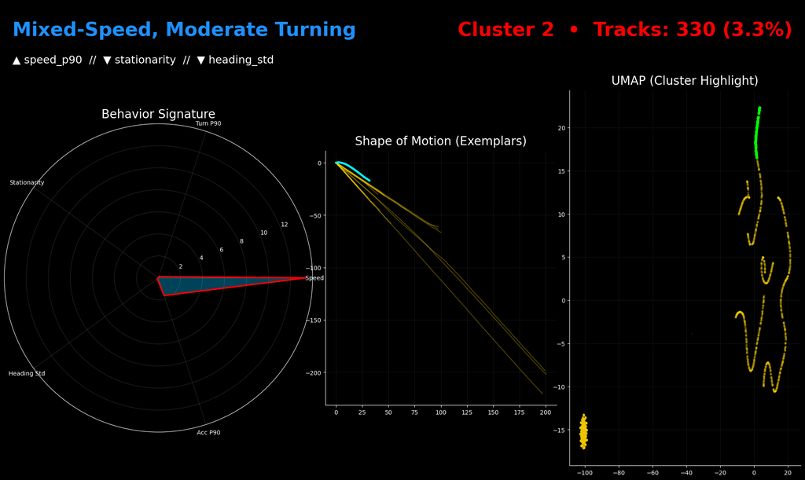

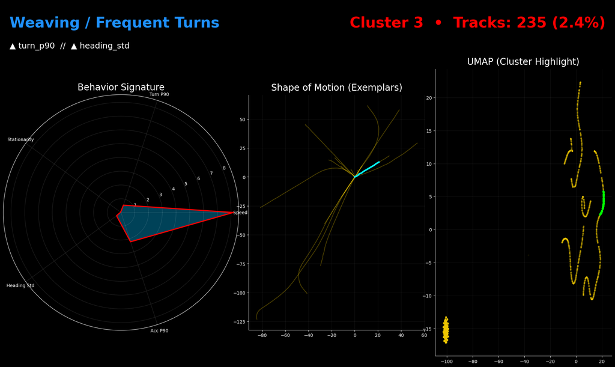

```python
# This cell will only run if the full computation is enabled.
if RUN_INTERPRETATION:
    # Pre-compute Trajectory Dictionary for Fast Plotting
    print("--- Building fast trajectory lookup dictionary ---")
    trajectories_dict = {}
    grouped = agents_df_clean.groupby(['scene_id', 'track_id'])
    for (sid, tid), g in tqdm(grouped, desc="Processing Trajectories"):
        sorted_g = g.sort_values('frame_idx')
        trajectories_dict[(sid, tid)] = {
            'x': sorted_g.x.to_numpy(),
            'y': sorted_g.y.to_numpy()
        }

    # UMAP Calculation for Visualization
    print("\n--- Calculating UMAP Embeddings for Visualization (see progress below) ---")
    reducer = umap.UMAP(
        n_neighbors=75,
        min_dist=0.05,
        metric="euclidean",
        random_state=SEED,
        n_components=2,
        verbose=True
    )
    U_cards = reducer.fit_transform(Z_cards)

    # Define Plotting Helpers & Pre-calculate Scenario Names
    metrics = ['med_speed_p90', 'med_turn_p90', 'med_stationarity', 'med_heading_std', 'med_acc_p90']
    g = cluster_summary[metrics].quantile([0.25, 0.5, 0.75]).to_dict()

    def _name_row(row):
        sp90 = row['med_speed_p90']; tr90 = row['med_turn_p90']
        stat = row['med_stationarity']; hstd = row['med_heading_std']; accp = row['med_acc_p90']
        if pd.isna(sp90): return "Unlabeled"
        if sp90 >= g['med_speed_p90'][0.75] and tr90 <= g['med_turn_p90'][0.25]: return "High-Speed, Straight"
        if stat >= 0.6 and accp >= g['med_acc_p90'][0.75]: return "Stop-and-Go"
        if hstd >= g['med_heading_std'][0.75] and tr90 >= g['med_turn_p90'][0.75]: return "Weaving / Frequent Turns"
        if sp90 <= g['med_speed_p90'][0.25] and stat >= 0.4: return "Slow / Lingering"
        return "Mixed-Speed, Moderate Turning"

    summary_z = cluster_summary[metrics].apply(lambda x: (x - x.mean()) / x.std()).fillna(0)
    def _get_distinguishing_features(cid, n=2):
        if cid not in summary_z.index: return ""
        z_scores = summary_z.loc[cid].sort_values(ascending=False)
        top = z_scores.head(n); low = z_scores.tail(n)
        chips = [f"▲ {name.replace('med_', '')}" for name in top.index if top[name] > 0.5]
        chips += [f"▼ {name.replace('med_', '')}" for name in low.index if low[name] < -0.5]
        return "  //  ".join(chips)

    cluster_summary['scenario_name'] = cluster_summary.apply(_name_row, axis=1)
    CARDS_DIR = ARTIFACT_DIR / "cards"; CARDS_DIR.mkdir(parents=True, exist_ok=True)
    WIN_CARDS_DIR = WINDOWS_MIRROR / "cards" if WINDOWS_MIRROR else None
    if WIN_CARDS_DIR: WIN_CARDS_DIR.mkdir(parents=True, exist_ok=True)

    # Define the Card Rendering Function
    def render_scenario_card(cid: int, display_in_notebook: bool = False):
        cluster_mask = (y_cards == cid)
        n_tracks = int(cluster_mask.sum())
        if n_tracks == 0: return None
        pct_tracks = 100.0 * n_tracks / len(y_cards)
        row = cluster_summary.loc[cluster_summary["cluster_id"]==cid].iloc[0]
        title_text = row['scenario_name']

        fig = plt.figure(figsize=(24, 14), facecolor="black")
        gs = fig.add_gridspec(2, 3, height_ratios=[0.4, 2], width_ratios=[1.2, 0.9, 0.9], hspace=0.05, wspace=0.05)

        # Header
        axH = fig.add_subplot(gs[0, :]); axH.set_facecolor("black"); axH.axis('off')
        axH.text(0.01, 0.65, title_text, color="dodgerblue", fontsize=32, fontweight="bold", ha="left", va="center")
        axH.text(0.01, 0.25, _get_distinguishing_features(cid), color="white", fontsize=18, ha="left", va="center")
        axH.text(0.99, 0.65, f"Cluster {cid}  •  Tracks: {n_tracks:,} ({pct_tracks:.1f}%)", color="red", fontsize=32, fontweight="bold", ha="right", va="center")

        # Radar Plot
        axR = fig.add_subplot(gs[1, 0], projection='polar', facecolor='black')
        axR.set_title("Behavior Signature", color="white", fontsize=20, pad=10)
        labels = [c.replace('med_', '').replace('_', ' ').title() for c in metrics]
        values = row[metrics].to_numpy(dtype=float)
        angles = np.linspace(0, 2 * np.pi, len(labels), endpoint=False).tolist()
        values_closed = np.concatenate((values, [values[0]])); angles_closed = angles + [angles[0]]
        axR.plot(angles_closed, values_closed, lw=2.5, color="red"); axR.fill(angles_closed, values_closed, alpha=0.35, color="deepskyblue")
        axR.set_thetagrids(np.degrees(angles), labels, color='white', fontsize=12); axR.tick_params(colors="white", labelsize=10)
        axR.spines["polar"].set_edgecolor("white"); axR.grid(color='white', alpha=0.15)

        # Shape of Motion Plot
        axS = fig.add_subplot(gs[1, 1]); axS.set_facecolor("black")
        axS.set_title("Shape of Motion (Exemplars)", color="white", fontsize=20, pad=10)
        def plot_trajectory(scene_id, track_id, **kwargs):
            traj_data = trajectories_dict.get((scene_id, track_id))
            if traj_data and len(traj_data['x']) > 1:
                x = traj_data['x'] - traj_data['x'][0]; y = traj_data['y'] - traj_data['y'][0]
                axS.plot(x, y, **kwargs)
        for ridx in sample_exemplars.get(cid, []):
            row = key_cards.iloc[ridx]
            plot_trajectory(row.scene_id, row.track_id, alpha=0.3, lw=1.5, color="gold")
        med_idx = centroid_exemplars.get(cid)
        if med_idx is not None:
            row = key_cards.iloc[med_idx]
            plot_trajectory(row.scene_id, row.track_id, alpha=0.95, lw=3.5, color="cyan")
        axS.tick_params(colors="white"); axS.grid(color='white', alpha=0.08); axS.set_aspect('equal', adjustable='box')
        for spine in ['left', 'bottom']: axS.spines[spine].set_color('white')
        for spine in ['right', 'top']: axS.spines[spine].set_visible(False)

        # UMAP Plot
        axU = fig.add_subplot(gs[1, 2]); axU.set_facecolor("black")
        axU.set_title("UMAP (Cluster Highlight)", color="white", fontsize=20, pad=10)
        axU.scatter(U_cards[:,0], U_cards[:,1], s=8, c='gold', alpha=0.05)
        axU.scatter(U_cards[cluster_mask,0], U_cards[cluster_mask,1], s=10, c='lime', alpha=0.85)
        axU.tick_params(colors="white"); axU.grid(color='white', alpha=0.08)
        for spine in ['left', 'bottom']: axU.spines[spine].set_color('white')
        for spine in ['right', 'top']: axU.spines[spine].set_visible(False)

        # Save and Display
        plt.tight_layout()
        save_path = CARDS_DIR / f"scenario_card_c{cid:02d}.png"
        fig.savefig(save_path, dpi=200, bbox_inches="tight", facecolor="black")
        if WIN_CARDS_DIR:
            try: shutil.copy2(save_path, WIN_CARDS_DIR)
            except Exception: pass
        if display_in_notebook: plt.show()
        plt.close(fig)
        return {'cluster_id': cid, 'title': title_text, 'path': save_path}

    # Render All Cards and Display a Subset
    display_counts = defaultdict(int); card_paths = []
    order = cluster_summary.sort_values('n_tracks', ascending=False)['cluster_id'].astype(int).tolist()
    for cid in tqdm(order, desc="Rendering Scenario Cards", unit="card"):
        title = cluster_summary.loc[cluster_summary.cluster_id == cid, 'scenario_name'].iloc[0]
        should_display = (display_counts[title] < 2)
        path_info = render_scenario_card(cid, display_in_notebook=should_display)
        if path_info: card_paths.append(path_info)
        if should_display: display_counts[title] += 1
else:
    print("--- Skipped: Loading from cache ---")
```

### 10.6 Scenario Gallery

This final visualization provides a high-level overview of the entire solution. It presents a gallery of thumbnails, where each thumbnail shows the location of a single cluster within the 2D UMAP projection of the latent space. This view helps to understand the relationships between clusters and the overall structure of the learned behavior manifold.

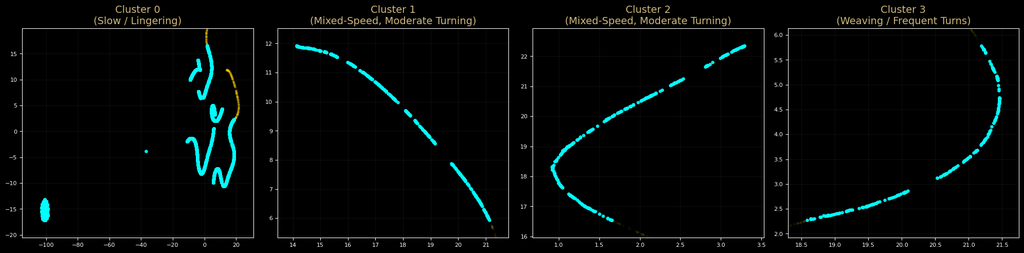

```
Figure saved to (Linux): /home/treinart/projects/lyft-unsupervised/artifacts/figures/20250917_221131_scenario_gallery.png
Figure saved to (Win):   /mnt/c/Users/travi/Documents/Training/Colorado/MS-AI/CSCA 5632 Final Project/artifacts/figures/20250917_221131_scenario_gallery.png
```

```python
# This cell will only run if the full computation is enabled.
if RUN_INTERPRETATION:
    # Determine Grid Layout and Create Figure
    C = len(cluster_summary)
    cols = min(4, C)
    rows = int(np.ceil(C/cols))
    fig, axes = plt.subplots(rows, cols, figsize=(20, 5 * rows), facecolor="black")
    axes = np.atleast_2d(axes).flatten()

    # Plot Each Cluster on its Own Subplot
    order = cluster_summary.sort_values('n_tracks', ascending=False)['cluster_id'].tolist()
    for i, cid in enumerate(order):
        ax = axes[i]
        ax.set_facecolor("black")
        cluster_mask = (y_cards == cid)

        # Plot all points as a background
        ax.scatter(U_cards[:,0], U_cards[:,1], s=6, c='gold', alpha=0.04)

        # Highlight the current cluster's points
        cluster_points = U_cards[cluster_mask]
        ax.scatter(cluster_points[:,0], cluster_points[:,1], s=14, c='cyan', alpha=0.9)

        # Zoom the axes to the highlighted cluster
        if cluster_points.shape[0] > 1:
            x_min, x_max = cluster_points[:, 0].min(), cluster_points[:, 0].max()
            y_min, y_max = cluster_points[:, 1].min(), cluster_points[:, 1].max()
            x_padding = (x_max - x_min) * 0.1; y_padding = (y_max - y_min) * 0.1
            ax.set_xlim(x_min - x_padding, x_max + x_padding)
            ax.set_ylim(y_min - y_padding, y_max + y_padding)

        # Style the plot
        scenario_name = cluster_summary[cluster_summary.cluster_id == cid]['scenario_name'].iloc[0]
        ax.set_title(f"Cluster {int(cid)}\n({scenario_name})", color="#CFB87C", fontsize=14, pad=6)
        ax.tick_params(colors="white", labelsize=8)
        for sp in ax.spines.values():
            sp.set_edgecolor("white")
        ax.grid(color='white', alpha=0.06)

    # Hide any unused subplots
    for j in range(i + 1, len(axes)):
        axes[j].axis('off')

    # Save the Final Gallery Figure
    save_fig(fig, "scenario_gallery")
else:
    print("--- Skipped: Loading from cache ---")
```

### 10.7 Deep Dive: Animating a Scenario Replay

As a final "show stopper" visualization, this cell renders an animated MP4 video replay of a single, representative scenario. It selects the exemplar track from one of the most interesting clusters ("Weaving / Frequent Turns") and animates the positions of all agents in that scene, highlighting the exemplar. This provides a dynamic, intuitive view of the discovered behavior in its original context.

```python
# This cell will only run if the full computation is enabled.
if RUN_INTERPRETATION:
    # Check if ffmpeg is available
    if shutil.which("ffmpeg") is None:
        print("--- ffmpeg not found. Skipping animation. ---")
    else:
        # Setup and Scene Selection
        VIDEO_DIR = ARTIFACT_DIR / "videos"; VIDEO_DIR.mkdir(exist_ok=True)
        WIN_VIDEO_DIR = WINDOWS_MIRROR / "videos" if WINDOWS_MIRROR else None
        if WIN_VIDEO_DIR: WIN_VIDEO_DIR.mkdir(parents=True, exist_ok=True)

        try: # Select a target cluster to animate
            target_cluster_id = cluster_summary[cluster_summary.scenario_name == "Weaving / Frequent Turns"].cluster_id.iloc[0]
        except IndexError: # Fallback if name isn't found
            target_cluster_id = cluster_summary.sort_values('n_tracks', ascending=False).iloc[2].cluster_id

        exemplar_info = key_cards.iloc[centroid_exemplars[target_cluster_id]]
        SCENE_TO_ANIMATE = exemplar_info.scene_id
        TRACK_TO_HIGHLIGHT = exemplar_info.track_id
        scene_df = agents_df_clean[agents_df_clean.scene_id == SCENE_TO_ANIMATE].copy()
        scene_frames = sorted(scene_df.frame_idx.unique())

        # Animation Setup
        COLOR_MODE = "cluster"
        scene_tracks = scene_df[["scene_id","track_id"]].drop_duplicates()
        track_clusters = scene_tracks.merge(final_clusters_df_ae, on=["scene_id","track_id"], how="left")
        unique_clusters = np.sort(track_clusters["cluster_id"].dropna().unique())
        base_cmap = cm.get_cmap("tab20", max(1, len(unique_clusters)))
        cluster_to_color = {int(cid): mcolors.to_hex(base_cmap(i)) for i, cid in enumerate(unique_clusters)}
        track_clusters['color'] = track_clusters['cluster_id'].apply(lambda cid: cluster_to_color.get(int(cid), "#6E6E6E") if pd.notna(cid) else "#6E6E6E")
        track_colors = pd.Series(track_clusters.color.values, index=track_clusters.track_id).to_dict()

        # Create the figure and draw static elements
        fig, ax = plt.subplots(figsize=(20, 20), facecolor="#0b0b0e")
        ax.set_facecolor("#0b0b0e")
        ax.tick_params(colors="white"); [s.set_edgecolor("white") for s in ax.spines.values()]
        for tid, track in scene_df.groupby('track_id'):
            if int(tid) == int(TRACK_TO_HIGHLIGHT): continue
            ax.plot(track.x.to_numpy(), track.y.to_numpy(), color=track_colors.get(int(tid), "#6E6E6E"), alpha=0.7, lw=2)
        highlighted_track = scene_df[scene_df["track_id"] == TRACK_TO_HIGHLIGHT]
        if not highlighted_track.empty:
            ax.plot(highlighted_track.x, highlighted_track.y, color="#0aa0b5", lw=4.5, alpha=0.6, zorder=2)
            ax.plot(highlighted_track.x, highlighted_track.y, color="#00e5ff", lw=2.2, alpha=0.95, zorder=3)
        x_min, x_max = scene_df.x.min(), scene_df.x.max(); y_min, y_max = scene_df.y.min(), scene_df.y.max()
        ax.set_xlim(x_min - 10, x_max + 10); ax.set_ylim(y_min - 10, y_max + 10)
        ax.set_aspect("equal", adjustable="box")
        frame_artists = []

        # Define the Animation Update Function
        def update(frame):
            if frame_artists: frame_artists[0].remove(); frame_artists.clear()
            frame_data = scene_df[scene_df.frame_idx == frame]
            if frame_data.empty: return []
            colors = ["#00e5ff" if int(tid) == int(TRACK_TO_HIGHLIGHT) else track_colors.get(int(tid), "#6E6E6E") for tid in frame_data['track_id']]
            quiver = ax.quiver(frame_data['x'], frame_data['y'], frame_data['vx'], frame_data['vy'], color=colors, headwidth=4, headlength=5, width=0.005, zorder=4)
            frame_artists.append(quiver)
            ax.set_title(f"Scene {SCENE_TO_ANIMATE} - Frame {frame}", color="#CFB87C", fontsize=16)
            return frame_artists

        # Generate, Save, and Display the Animation
        print(f"Generating animation for Scene {SCENE_TO_ANIMATE}")
        pbar = tqdm(total=len(scene_frames), desc="Saving Animation")
        ani = animation.FuncAnimation(fig, update, frames=scene_frames, blit=False, interval=100)
        timestamp = time.strftime("%Y%m%d_%H%M%S")
        save_path = VIDEO_DIR / f"scenario_replay_{COLOR_MODE}_{timestamp}.mp4"
        ani.save(save_path, writer='ffmpeg', dpi=150, progress_callback=lambda i, n: pbar.update(1))
        pbar.close(); plt.close(fig)

        # Mirror and print confirmation
        print(f"\nAnimation Saved\n  - Linux: {save_path.resolve()}")
        if WIN_VIDEO_DIR:
            try:
                shutil.copy2(save_path, WIN_VIDEO_DIR)
                print(f"  - Win:   {WIN_VIDEO_DIR / save_path.name}")
            except Exception as e:
                print(f"Mirror Warning: {e}")

else:
    print("--- Skipped: Loading from cache ---")
```

```
Generating animation for Scene 10600
```

```
Animation Saved
  - Linux: /home/treinart/projects/lyft-unsupervised/artifacts/videos/scenario_replay_cluster_20250917_221138.mp4
  - Win:   /mnt/c/Users/travi/Documents/Training/Colorado/MS-AI/CSCA 5632 Final Project/artifacts/videos/scenario_replay_cluster_20250917_221138.mp4
```

```python
# Optional: Display the animation in the notebook (can be slow/large)
display(HTML(ani.to_html5_video()))
```

[video not shown]

### **Observation: Visualizing Trajectory Behavior**

**What this section delivers.**  
Section 10 turns the clustering from Section 9 into interpretable behavior. It provides per-track signatures, cluster-level profiles, scenario cards for each cluster, a gallery that shows where those behaviors live in the embedding, and a short replay that lets the motion be seen over time.

**Cluster makeup at a glance.**  
From the profile table:

- **Cluster 0: Slow / Lingering** - 8,964 tracks, **90.1%** of all tracks. Median stationarity ≈ **1.00** with near-zero speed.
- **Cluster 1: Mixed-speed, Moderate Turning** - 415 tracks, **4.2%**. Median speed p50 ≈ **12.8**, modest turning and heading variation.
- **Cluster 2: Mixed-speed, Moderate Turning** - 330 tracks, **3.3%**. Similar regime to Cluster 1 with slightly lower accel p90.
- **Cluster 3: Weaving / Frequent Turns** - 235 tracks, **2.4%**. Lower median speed p50 ≈ **5.0** but **higher** turning and heading variability (turn_p90 ≈ **0.56**, heading_std ≈ **0.40**).

**Reading a scenario card**  
Each card has three coordinated views:

1. **Behavior Signature (radar).**
   - **Cluster 0** spikes on **stationarity** and sits near the origin for speed, accel, and turning. This confirms the long tail of idle or near-idle tracks.
   - **Cluster 3** elevates **turn_p90** and **heading_std** with moderate **acc_p90**, the hallmark of weaving.
2. **Shape of Motion (exemplars).**
   - **Cluster 0** shows short, jittery traces that stay close to a point or creep slowly, consistent with lingering.
   - **Cluster 1 and 2** produce longer, mostly smooth arcs with moderate curvature.
   - **Cluster 3** contains trajectories with repeated heading changes and small S-curves, matching the radar signature.
3. **UMAP highlight.**
   - **Cluster 0** occupies a compact island, separated from the more dynamic clusters.
   - **Clusters 1 and 2** live on nearby arcs along the same manifold, indicating related motion regimes.
   - **Cluster 3** concentrates in a distinct neighborhood where curvature and heading variance rise.

**Scenario gallery**  
The gallery places an exemplar path for each cluster on its local UMAP neighborhood. The cyan traces show representative shapes while the yellow points provide nearby context. The result is a quick visual index: idle behavior in its own pocket, two mixed-speed regimes along smooth arcs, and a weaving pocket that is clearly distinct.

**Per-track signatures**  
The table confirms what the cards show at micro scale. Examples in scenes with **stationarity ≈ 1.0** land in Cluster 0. Tracks with **speed_p90 near 13** and **low turn_p90** map to Clusters 1 or 2. Rows with **large turn_p90** and **higher heading_std** correspond to Cluster 3. These fields give a compact, queryable summary for downstream search and filtering.

**Centroid exemplars**  
For each cluster, a single scene_id and track_id are identified as closest to the cluster center. These are the most “typical” representatives and are the right choices for documentation, QA spot checks, and replay.

**Video replay**  
The MP4 for **Scene 10600** showcases the Cluster 3 exemplar. The agent advances with frequent heading changes, short bursts of acceleration, and visible curvature. The motion is consistent with the **Weaving / Frequent Turns** label and mirrors the elevated **turn_p90** and **heading_std** seen in the card.

**Conclusion**  
The visuals line up with the statistics: a dominant slow or lingering population, two clean mixed-speed regimes with modest curvature, and a small but well-separated weaving group. The agreement between radar signatures, exemplar shapes, UMAP neighborhoods, per-track tables, and the replay builds confidence that the clusters correspond to real, interpretable behaviors.

## Section 11: Pipeline Comparison

This section performs a final, side-by-side comparison of Pipeline A (classical features) and Pipeline B (learned embeddings). The analysis involves measuring the agreement between the two sets of cluster assignments and visualizing the differences. This allows for a data-driven conclusion on which approach produced a more effective or insightful clustering solution.

### Section Plan

**Data Loading & Alignment:** Load all necessary artifacts, align Pipeline B's labels to Pipeline A's, and compute agreement metrics.

**Visualization Utilities:** Define helper functions for creating palettes and rendering scene backdrops.

**Side-by-Side Scene Viewer:** Visualize the differences in cluster assignments for a sample scene.

**Aligned Exemplar Gallery:** Compare the most representative tracks from aligned cluster pairs.

**Alignment Scorecard:** Create a detailed summary plot comparing the feature profiles for each archetype.

**Export Final Comparison:** Package all comparison tables into a final, multi-sheet Excel spreadsheet.

### 11.1 Data Loading & Label Alignment

This cell loads all the necessary final artifacts from both Pipeline A and Pipeline B. It finds the common set of tracks clustered by both pipelines, aligns the labels from Pipeline B to match Pipeline A, and computes global agreement statistics like ARI and NMI.

```python
# Load Final Artifacts from Both Pipelines
print("--- Loading Final Artifacts ---")
clusters_a = pd.read_parquet(ARTIFACT_DIR / "pipeline_a_cluster_assignments.parquet")
clusters_b = pd.read_parquet(ARTIFACT_DIR / "pipeline_b_cluster_assignments.parquet")
features_a = pd.read_parquet(ARTIFACT_DIR / "pipeline_a_features.parquet")
embeddings_b = pd.read_parquet(ARTIFACT_DIR / "pipeline_b_track_embeddings.parquet")
print("Loaded cluster assignments, features, and embeddings for both pipelines.")

# Define the Label Alignment Function Here
def align_labels(y_true: np.ndarray, y_pred: np.ndarray):
    # ignore noise if present
    mask = (y_true != -1) & (y_pred != -1)
    A_labs = np.unique(y_true[mask])
    B_labs = np.unique(y_pred[mask])
    cm = confusion_matrix(y_true[mask], y_pred[mask], labels=A_labs)
    cost = cm.max() - cm
    row_ind, col_ind = linear_sum_assignment(cost)
    map_B2A = {int(B_labs[j]): int(A_labs[i]) for i, j in zip(row_ind, col_ind)}
    y_aligned = np.array([map_B2A.get(int(lbl), -1) if lbl != -1 else -1 for lbl in y_pred], dtype=int)
    return y_aligned, map_B2A, cm

# Find the Intersection of Tracks
alignment_tbl = clusters_a.merge(clusters_b, on=["scene_id", "track_id"], suffixes=("_A", "_B"))
print(f"\nFound {len(alignment_tbl):,} shared tracks across both pipelines for comparison.")

# Align Pipeline B Labels to Pipeline A
yA = alignment_tbl["cluster_id_A"].to_numpy()
yB = alignment_tbl["cluster_id_B"].to_numpy()
yB_aligned, map_B2A, _ = align_labels(yA, yB)
alignment_tbl["cluster_B_aligned"] = yB_aligned
alignment_tbl["agree"] = (yA == yB_aligned)

# Compute and Display Global Agreement Metrics
global_stats = pd.DataFrame([{
    "tracks_compared": len(yA), "k_A": len(np.unique(yA)), "k_B": len(np.unique(yB)),
    "ARI(A, B_aligned)": ARI(yA, yB_aligned), "NMI(A, B_aligned)": NMI(yA, yB_aligned),
    "Agreement_Rate": (yA == yB_aligned).mean()
}])
print("\n--- Global Alignment & Agreement ---")
display(style_section_table(global_stats.round(4)))

# Compute and Display Per-Cluster Overlap
A_labels = np.unique(yA)
overlap_rows = []
for ca in A_labels:
    mask_a = (yA == ca)
    vals, counts = np.unique(yB_aligned[mask_a], return_counts=True)
    if len(vals):
        b_mode = int(vals[counts.argmax()])
        overlap = float(counts.max() / mask_a.sum())
    else:
        b_mode, overlap = -1, 0.0
    overlap_rows.append({"cluster_A": int(ca), "A_count": int(mask_a.sum()),
                         "B_mode_aligned": b_mode, "overlap_rate": overlap})
overlap_df = pd.DataFrame(overlap_rows).sort_values("cluster_A")


# Save Alignment Artifacts
ALIGN_DIR = ARTIFACT_DIR / "compare_ab"; ALIGN_DIR.mkdir(parents=True, exist_ok=True)
alignment_tbl.to_parquet(ALIGN_DIR / "alignment_table.parquet", index=False)
with open(ALIGN_DIR / "label_map_B_to_A.json","w") as f: json.dump({int(k): int(v) for k,v in map_B2A.items()}, f, indent=2)
global_stats.to_parquet(ALIGN_DIR / "global_stats.parquet", index=False)
overlap_df.to_parquet(ALIGN_DIR / "overlap_by_cluster.parquet", index=False)
print(f"\n[Saved] Alignment artifacts -> {ALIGN_DIR}")
```

```
--- Loading Final Artifacts ---
Loaded cluster assignments, features, and embeddings for both pipelines.

Found 7,824 shared tracks across both pipelines for comparison.

--- Global Alignment & Agreement ---
```

| tracks_compared | k_A | k_B | ARI(A, B_aligned) | NMI(A, B_aligned) | Agreement_Rate |
| --- | --- | --- | --- | --- | --- |
| 7824 | 4 | 4 | 0.262500 | 0.369800 | 0.651200 |

```
[Saved] Alignment artifacts -> /home/treinart/projects/lyft-unsupervised/artifacts/compare_ab
```

### 11.2 Visualization Utilities

```python
# Palette and BEV Helpers
def cluster_palette(n, seed=7):
    rng = np.random.default_rng(seed)
    base = plt.get_cmap("tab20").colors
    cols = [base[i % len(base)] for i in range(n)]
    rng.shuffle(cols)
    return {i: cols[i] for i in range(n)}

PALETTE_A = cluster_palette(clusters_a["cluster_id"].nunique(), seed=13)
PALETTE_B_ALIGNED = PALETTE_A

def bev_from_scene(scene_df, bins=300):
    xy = scene_df[["x","y"]].to_numpy(dtype=float)
    if len(xy) == 0: return np.zeros((bins,bins)), (0,1,0,1)
    x_min, x_max = xy[:,0].min(), xy[:,0].max(); y_min, y_max = xy[:,1].min(), xy[:,1].max()
    H, _, _ = np.histogram2d(xy[:,0], xy[:,1], bins=bins, range=[[x_min,x_max],[y_min,y_max]])
    H = np.log1p(H.T)
    return H, [x_min, x_max, y_min, y_max]

def draw_bev(ax, H, extent, alpha=0.35):
    ax.imshow(H, extent=extent, origin="lower", cmap="Greys", alpha=alpha)

def track_xyv(agents, sid, tid):
    g = agents[(agents.scene_id==sid) & (agents.track_id==tid)].sort_values("frame_idx")
    return g["x"].to_numpy(), g["y"].to_numpy(), g["vx"].to_numpy(), g["vy"].to_numpy()

# Sanity Check Printout
print("-" * 70)
print("--- Visualization Utilities Ready ---")
print(f"  - PALETTE_A created with {len(PALETTE_A)} colors: {dict(list(PALETTE_A.items())[:3])}...")
print(f"  - Helper functions defined: cluster_palette, bev_from_scene, draw_bev, track_xyv")
print("-" * 70)
```

```
----------------------------------------------------------------------
--- Visualization Utilities Ready ---
  - PALETTE_A created with 4 colors: {0: (1.0, 0.7333333333333333, 0.47058823529411764), 1: (1.0, 0.4980392156862745, 0.054901960784313725), 2: (0.6823529411764706, 0.7803921568627451, 0.9098039215686274)}...
  - Helper functions defined: cluster_palette, bev_from_scene, draw_bev, track_xyv
----------------------------------------------------------------------
```

### 11.3 Side-by-Side Scene Viewer

```
--- Rendering Top 4 Busiest Scenes for Comparison ---

--- Displaying Scene 15692 ---
```

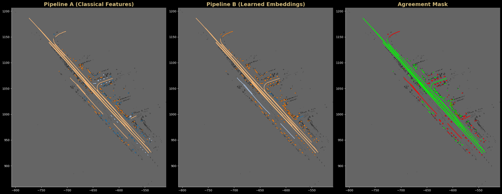

```
Figure saved to (Linux): /home/treinart/projects/lyft-unsupervised/artifacts/figures/20250917_221439_scene_compare_15692.png
Figure saved to (Win):   /mnt/c/Users/travi/Documents/Training/Colorado/MS-AI/CSCA 5632 Final Project/artifacts/figures/20250917_221439_scene_compare_15692.png

--- Displaying Scene 7144 ---
```

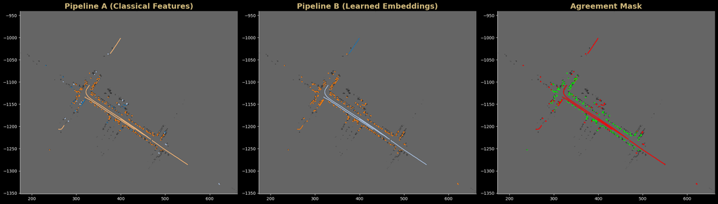

```
Figure saved to (Linux): /home/treinart/projects/lyft-unsupervised/artifacts/figures/20250917_221440_scene_compare_7144.png
Figure saved to (Win):   /mnt/c/Users/travi/Documents/Training/Colorado/MS-AI/CSCA 5632 Final Project/artifacts/figures/20250917_221440_scene_compare_7144.png

--- Displaying Scene 7143 ---
```

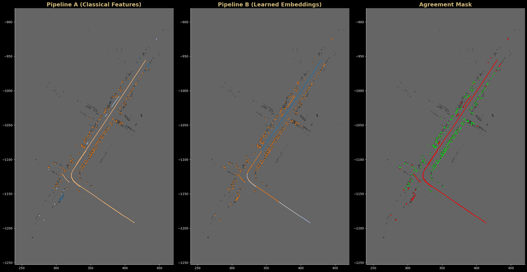

```
Figure saved to (Linux): /home/treinart/projects/lyft-unsupervised/artifacts/figures/20250917_221441_scene_compare_7143.png
Figure saved to (Win):   /mnt/c/Users/travi/Documents/Training/Colorado/MS-AI/CSCA 5632 Final Project/artifacts/figures/20250917_221441_scene_compare_7143.png

--- Displaying Scene 1174 ---
```

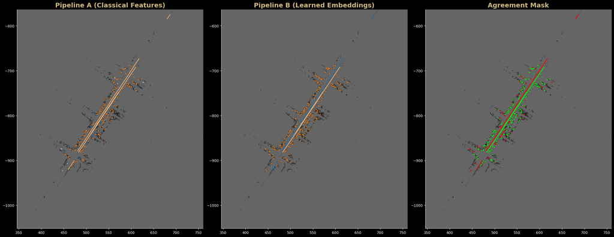

```
Figure saved to (Linux): /home/treinart/projects/lyft-unsupervised/artifacts/figures/20250917_221443_scene_compare_1174.png
Figure saved to (Win):   /mnt/c/Users/travi/Documents/Training/Colorado/MS-AI/CSCA 5632 Final Project/artifacts/figures/20250917_221443_scene_compare_1174.png
```

```python
# Define the Scene Viewer Function
def render_scene_compare(scene_id: int):
    df_scene = agents_df_clean[agents_df_clean.scene_id==scene_id]
    if df_scene.empty: print(f"Scene {scene_id} not found."); return
    assign = alignment_tbl[alignment_tbl.scene_id==scene_id]
    H, extent = bev_from_scene(df_scene, bins=280)

    # Create the plot canvas
    fig, axes = plt.subplots(1, 3, figsize=(24,12), facecolor="black")
    titles = ["Pipeline A (Classical Features)", "Pipeline B (Learned Embeddings)", "Agreement Mask"]
    for ax, t in zip(axes, titles):
        ax.set_facecolor("black"); draw_bev(ax, H, extent, alpha=0.40)
        ax.set_title(t, fontsize=18, color="#CFB87C", fontweight="bold")
        ax.tick_params(colors="white"); [sp.set_color("white") for sp_n, sp in ax.spines.items() if sp_n in ["left","bottom"]]
        [sp.set_visible(False) for sp_n, sp in ax.spines.items() if sp_n in ["right","top"]]

    # Plot trajectories for each panel
    for _, row in assign.iterrows():
        tid = int(row.track_id)
        x,y,_,_ = track_xyv(df_scene, scene_id, tid)

        # Use the correct column names: 'cluster_id_A' and 'cluster_B_aligned'
        color_a = PALETTE_A.get(int(row.cluster_id_A), "grey")
        color_b = PALETTE_B_ALIGNED.get(int(row.cluster_B_aligned), "grey")
        color_agree = "lime" if bool(row.agree) else "red"

        axes[0].plot(x, y, color=color_a, lw=1.8, alpha=0.9)
        axes[1].plot(x, y, color=color_b, lw=1.8, alpha=0.9)
        axes[2].plot(x, y, color="dimgrey", lw=1.0, alpha=0.6)
        axes[2].plot(x, y, color=color_agree, lw=2.0, alpha=0.9)


    save_fig(fig, f"scene_compare_{scene_id}")

# Render the comparison for the top 4 busiest scenes
top_4_scenes = alignment_tbl["scene_id"].value_counts().nlargest(4).index.tolist()
print(f"--- Rendering Top 4 Busiest Scenes for Comparison ---")
for scene_id in top_4_scenes:
    print(f"\n--- Displaying Scene {scene_id} ---")
    render_scene_compare(scene_id)
```

### 11.4 Aligned Exemplar Gallery

For each of Pipeline A's clusters, this gallery shows the most representative track ("centroid exemplar") from Pipeline A alongside the exemplar for the Pipeline B cluster that best aligns with it. This provides a direct, qualitative comparison of the core behavior captured by each pipeline's corresponding clusters.

```
--- Rendering 4 Aligned Exemplar Plots (Individual) ---
```

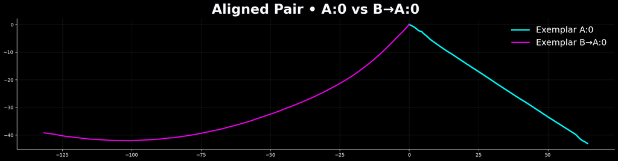

```
Figure saved to (Linux): /home/treinart/projects/lyft-unsupervised/artifacts/figures/20250917_221451_aligned_pair_A0_B0.png
Figure saved to (Win):   /mnt/c/Users/travi/Documents/Training/Colorado/MS-AI/CSCA 5632 Final Project/artifacts/figures/20250917_221451_aligned_pair_A0_B0.png
```

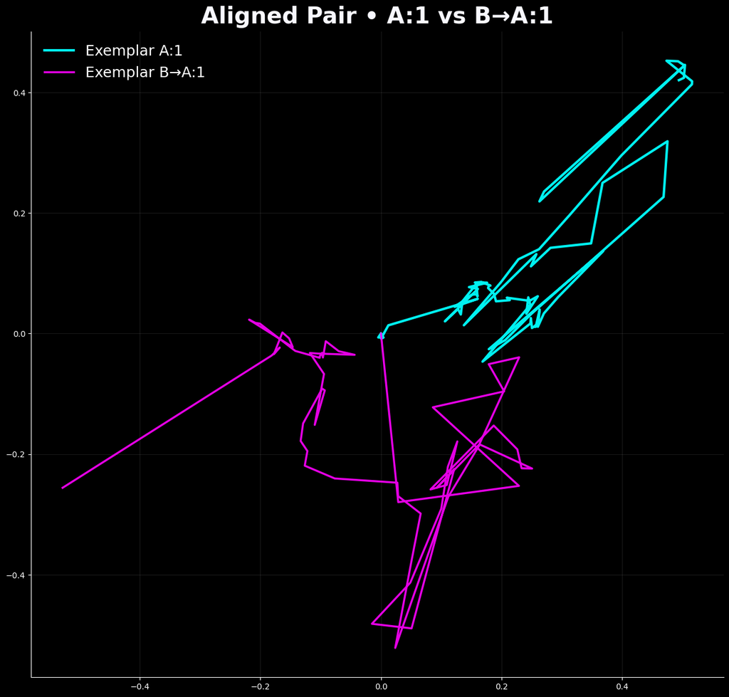

```
Figure saved to (Linux): /home/treinart/projects/lyft-unsupervised/artifacts/figures/20250917_221451_aligned_pair_A1_B1.png
Figure saved to (Win):   /mnt/c/Users/travi/Documents/Training/Colorado/MS-AI/CSCA 5632 Final Project/artifacts/figures/20250917_221451_aligned_pair_A1_B1.png
```

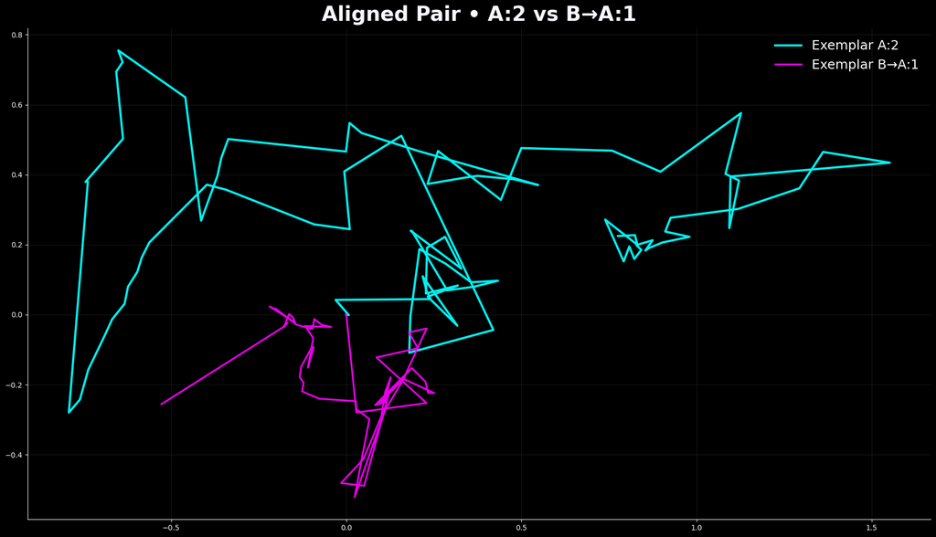

```
Figure saved to (Linux): /home/treinart/projects/lyft-unsupervised/artifacts/figures/20250917_221451_aligned_pair_A2_B1.png
Figure saved to (Win):   /mnt/c/Users/travi/Documents/Training/Colorado/MS-AI/CSCA 5632 Final Project/artifacts/figures/20250917_221451_aligned_pair_A2_B1.png
```

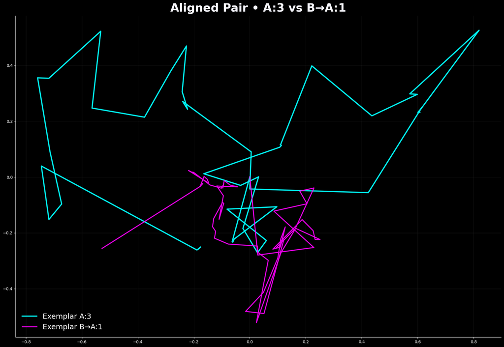

```
Figure saved to (Linux): /home/treinart/projects/lyft-unsupervised/artifacts/figures/20250917_221451_aligned_pair_A3_B1.png
Figure saved to (Win):   /mnt/c/Users/travi/Documents/Training/Colorado/MS-AI/CSCA 5632 Final Project/artifacts/figures/20250917_221451_aligned_pair_A3_B1.png
```

```python
# Prepare Data and Find Exemplars in Both Spaces
A_cols = [c for c in features_a.columns if c not in ["scene_id", "track_id"]]
B_cols = [c for c in embeddings_b.columns if c not in ["scene_id", "track_id"]]
A_space = features_a.merge(clusters_a, on=["scene_id","track_id"])
B_space = embeddings_b.merge(clusters_b, on=["scene_id","track_id"])
def find_exemplars(df_space, feature_cols, label_col="cluster_id"):
    exemplars = {}
    for cid, grp in df_space.groupby(label_col):
        M = grp[feature_cols].to_numpy(dtype=float)
        if len(M) == 0: continue
        centroid = M.mean(axis=0, keepdims=True)
        idx = int(np.argmin(np.linalg.norm(M - centroid, axis=1)))
        row = grp.iloc[idx]
        exemplars[int(cid)] = (int(row.scene_id), int(row.track_id))
    return exemplars
exemplars_A = find_exemplars(A_space, A_cols, "cluster_id")
exemplars_B = find_exemplars(B_space, B_cols, "cluster_id")

# Create a Separate Plot for Each Aligned Pair
A2B = {v: k for k, v in map_B2A.items()}

pairs = list(zip(overlap_df.cluster_A, overlap_df.B_mode_aligned))
print(f"--- Rendering {len(pairs)} Aligned Exemplar Plots (Individual) ---")

for ca, cb_aligned in pairs:
    fig, ax = plt.subplots(figsize=(18, 12), facecolor="black")
    ax.set_facecolor("black")
    sid_tid_A = exemplars_A.get(int(ca))
    cb_orig = A2B.get(int(cb_aligned), None)
    sid_tid_B = exemplars_B.get(cb_orig) if cb_orig is not None else None
    if sid_tid_A:
        x,y,_,_ = track_xyv(agents_df_clean, sid_tid_A[0], sid_tid_A[1])
        ax.plot(x - x[0], y - y[0], lw=3.0, alpha=0.95, color="cyan", label=f"Exemplar A:{ca}")
    if sid_tid_B:
        x,y,_,_ = track_xyv(agents_df_clean, sid_tid_B[0], sid_tid_B[1])
        ax.plot(x - x[0], y - y[0], lw=2.5, alpha=0.9, color="magenta", label=f"Exemplar B→A:{cb_aligned}")

    ax.set_title(f"Aligned Pair • A:{ca} vs B→A:{cb_aligned}", fontsize=28, color="ghostwhite", fontweight="bold", pad=10)
    ax.tick_params(colors="white")
    [sp.set_color("white") for name, sp in ax.spines.items() if name in ["left","bottom"]]
    [sp.set_visible(False) for name, sp in ax.spines.items() if name in ["right","top"]]
    ax.legend(frameon=False, labelcolor="white", fontsize=18)
    ax.set_aspect('equal', adjustable='box')
    ax.grid(color='white', alpha=0.1)

    # Save the figure with a unique name
    save_fig(fig, f"aligned_pair_A{int(ca)}_B{int(cb_aligned)}")
```

### 11.5 Alignment Scorecard

This final visualization provides the most direct comparison between the two pipelines. For each of Pipeline A's core archetypes, a scorecard is generated. Each card shows the visual shape of the archetype, a side-by-side feature fingerprint, comparing its profile to its aligned counterpart from Pipeline B, and the final agreement score. This provides a view of how well the pipelines agree on the definition of each discovered behavior.

```
--- Rendering 4 Alignment Scorecard Plots ---
```

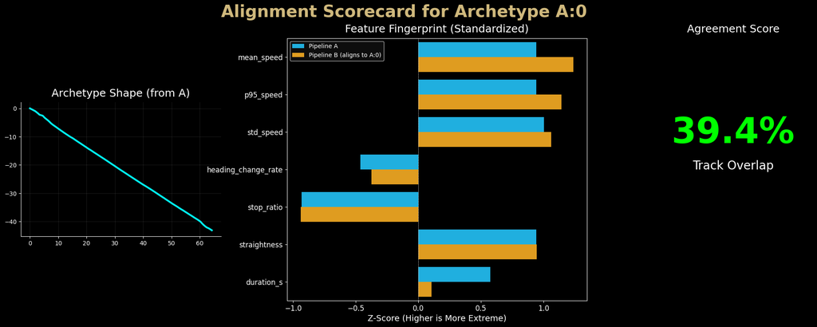

```
Figure saved to (Linux): /home/treinart/projects/lyft-unsupervised/artifacts/figures/20250917_221504_alignment_scorecard_A0.png
Figure saved to (Win):   /mnt/c/Users/travi/Documents/Training/Colorado/MS-AI/CSCA 5632 Final Project/artifacts/figures/20250917_221504_alignment_scorecard_A0.png
```

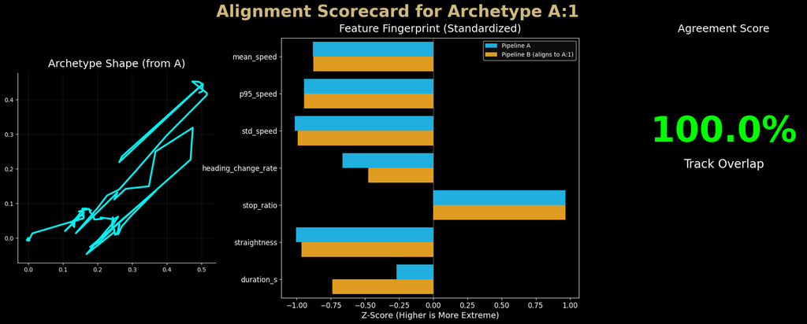

```
Figure saved to (Linux): /home/treinart/projects/lyft-unsupervised/artifacts/figures/20250917_221504_alignment_scorecard_A1.png
Figure saved to (Win):   /mnt/c/Users/travi/Documents/Training/Colorado/MS-AI/CSCA 5632 Final Project/artifacts/figures/20250917_221504_alignment_scorecard_A1.png
```

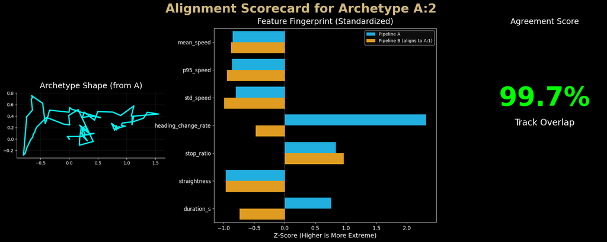

```
Figure saved to (Linux): /home/treinart/projects/lyft-unsupervised/artifacts/figures/20250917_221504_alignment_scorecard_A2.png
Figure saved to (Win):   /mnt/c/Users/travi/Documents/Training/Colorado/MS-AI/CSCA 5632 Final Project/artifacts/figures/20250917_221504_alignment_scorecard_A2.png
```

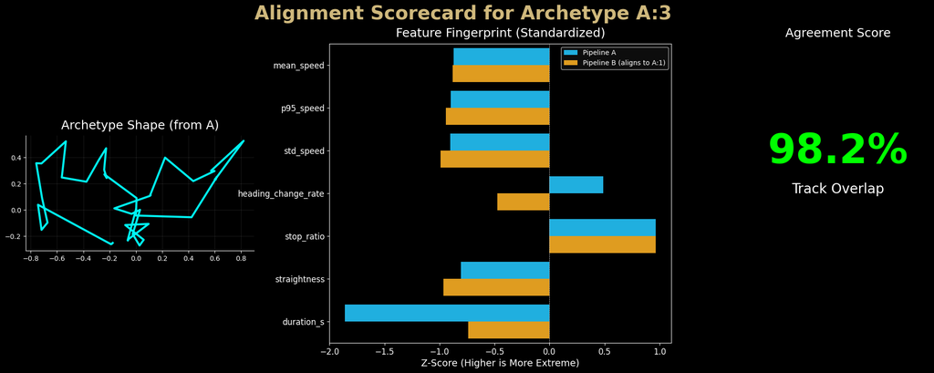

```
Figure saved to (Linux): /home/treinart/projects/lyft-unsupervised/artifacts/figures/20250917_221505_alignment_scorecard_A3.png
Figure saved to (Win):   /mnt/c/Users/travi/Documents/Training/Colorado/MS-AI/CSCA 5632 Final Project/artifacts/figures/20250917_221505_alignment_scorecard_A3.png
```

```python
# Prepare Data for Scorecard
feature_cols_to_profile = [
    "mean_speed", "p95_speed", "std_speed",
    "heading_change_rate", "stop_ratio", "straightness", "duration_s"
]
# Profile for Pipeline A
profiles_a_input = features_a.merge(clusters_a, on=["scene_id", "track_id"])
profiles_a = profiles_a_input.groupby("cluster_id")[feature_cols_to_profile].median()

# Profile for Pipeline B (using its aligned cluster IDs)
profiles_b_input = features_a.merge(alignment_tbl, on=["scene_id", "track_id"])
profiles_b_aligned = profiles_b_input.groupby("cluster_B_aligned")[feature_cols_to_profile].median()

# Standardize all profiles for fair comparison in the bar charts
all_profiles = pd.concat([profiles_a, profiles_b_aligned])
profiles_mean = all_profiles.mean()
profiles_std = all_profiles.std()
profiles_a_z = (profiles_a - profiles_mean) / profiles_std
profiles_b_aligned_z = (profiles_b_aligned - profiles_mean) / profiles_std

# Get the list of aligned cluster pairs to plot
pairs = list(zip(overlap_df.cluster_A, overlap_df.B_mode_aligned))
print(f"--- Rendering {len(pairs)} Alignment Scorecard Plots ---")

# Loop Through Each Pair and Create a Scorecard
for ca, cb_aligned in pairs:
    fig = plt.figure(figsize=(24, 8), facecolor="black")
    gs = fig.add_gridspec(1, 3, width_ratios=[1, 1.5, 0.8], wspace=0.3)
    fig.suptitle(f"Alignment Scorecard for Archetype A:{ca}", fontsize=28, color="#CFB87C", fontweight="bold")

    # Panel 1: Archetype Shape
    ax_shape = fig.add_subplot(gs[0, 0]); ax_shape.set_facecolor("black")
    ax_shape.set_title("Archetype Shape (from A)", fontsize=18, color="white", pad=10)
    sid_tid_A = exemplars_A.get(ca)
    if sid_tid_A:
        x,y,_,_ = track_xyv(agents_df_clean, sid_tid_A[0], sid_tid_A[1])
        ax_shape.plot(x - x[0], y - y[0], lw=3.0, alpha=0.95, color="cyan")
    ax_shape.set_aspect('equal', adjustable='box'); ax_shape.tick_params(colors="white"); ax_shape.grid(color='white', alpha=0.1)
    [sp.set_color("white") for name, sp in ax_shape.spines.items() if name in ["left","bottom"]]
    [sp.set_visible(False) for name, sp in ax_shape.spines.items() if name in ["right","top"]]

    # Panel 2: Feature Fingerprint (Side-by-side Bar Chart)
    ax_fp = fig.add_subplot(gs[0, 1]); ax_fp.set_facecolor("black")
    ax_fp.set_title("Feature Fingerprint (Standardized)", fontsize=18, color="white", pad=10)
    profile_a_data = profiles_a_z.loc[ca].rename("Pipeline A")
    profile_b_data = profiles_b_aligned_z.loc[cb_aligned].rename(f"Pipeline B (aligns to A:{cb_aligned})")
    plot_df = pd.concat([profile_a_data, profile_b_data], axis=1).reset_index().melt(id_vars="index", var_name="Pipeline", value_name="Z-Score")
    sns.barplot(data=plot_df, y="index", x="Z-Score", hue="Pipeline", ax=ax_fp, palette=["deepskyblue", "orange"], orient='h')
    ax_fp.axvline(0, color='white', lw=0.5, ls='--')
    ax_fp.tick_params(colors="white", labelsize=12); ax_fp.set_ylabel(""); ax_fp.set_xlabel("Z-Score (Higher is More Extreme)", color="white", fontsize=14)
    ax_fp.legend(facecolor="#111111", labelcolor="white"); [sp.set_color("white") for sp in ax_fp.spines.values()]

    # Panel 3: Agreement Score
    ax_stats = fig.add_subplot(gs[0, 2]); ax_stats.set_facecolor("black"); ax_stats.axis('off')
    ax_stats.set_title("Agreement Score", fontsize=18, color="white", pad=10)
    overlap = overlap_df[overlap_df.cluster_A == ca]['overlap_rate'].iloc[0]
    ax_stats.text(0.5, 0.6, f"{overlap:.1%}", fontsize=60, color="lime", ha="center", fontweight="bold")
    ax_stats.text(0.5, 0.5, "Track Overlap", fontsize=20, color="white", ha="center")

    # Save the figure
    save_fig(fig, f"alignment_scorecard_A{ca}")
```

### 11.6 Create Master Comparison Spreadsheets

This final cell synthesizes the full pipeline comparison into a comprehensive, shareable artifact. It creates three detailed tables:

- A detailed **Track-by-Track Comparison**
- A **Scene-Level Summary** sorted by disagreement
- A **Cluster-Level Summary** of agreement rates

These tables are then saved as a single, multi-sheet Excel file, providing the definitive, machine-readable output of the project's analysis.

```python
# Create Master Spreadsheets for Final Analysis

print("--- Building Master Comparison Spreadsheets (Track, Scene, and Cluster level) ---")

# Load necessary artifacts from previous sections
ALIGN_DIR = ARTIFACT_DIR / "compare_ab"
alignment_tbl = pd.read_parquet(ALIGN_DIR / "alignment_table.parquet")
features_a = pd.read_parquet(ARTIFACT_DIR / "pipeline_a_features.parquet")
with open(ALIGN_DIR / "label_map_B_to_A.json", 'r') as f: map_B2A = {int(k): v for k,v in json.load(f).items()}

# Manually define the scenario names for BOTH pipelines based on our analysis
map_a = {
    0: "High-Speed Cruising",
    1: "Stationary",
    2: "Low-Speed Maneuvering",
    3: "Idling and Creeping"
}

map_b = {
    0: "Stationary",
    1: "High-Speed (Curved)",
    2: "High-Speed (Straight)",
    3: "Moderate-Speed Cruising"
}

# Create the final mapping for the aligned B clusters
map_b_aligned = {v: map_b.get(k, "Unknown") for k, v in map_B2A.items()}

# Build the track-level master table
master_tracks = alignment_tbl.merge(features_a, on=["scene_id", "track_id"], how="left")
master_tracks["scenario_A"] = master_tracks["cluster_id_A"].map(map_a)
master_tracks["scenario_B_aligned"] = master_tracks["cluster_B_aligned"].map(map_b_aligned)

# Build the scene-level summary
scene_summary = master_tracks.groupby("scene_id").agg(
    n_tracks = ("track_id", "nunique"),
    agreement_rate = ("agree", "mean"),
    median_speed = ("mean_speed", "median"),
    median_turn_rate = ("heading_change_rate", "median"),
    median_stop_ratio = ("stop_ratio", "median")
).reset_index()
def describe_scene(row):
    density = "dense" if row["n_tracks"] >= 150 else ("moderate" if row["n_tracks"] >= 50 else "sparse")
    speed = "fast" if row["median_speed"] > 5 else ("slow" if row["median_speed"] < 2 else "mixed")
    flow = "stop-and-go" if row["median_stop_ratio"] > 0.25 else "free-flow"
    return f"{density.title()} traffic, {speed.title()} speed, {flow.title()}"
scene_summary["scene_description"] = scene_summary.apply(describe_scene, axis=1)
scene_summary = scene_summary.sort_values("agreement_rate", ascending=True)

# Build the cluster-level summary
cluster_summary_a = master_tracks.groupby(["cluster_id_A", "scenario_A"]).agg(
    n_tracks = ("track_id", "nunique"),
    agreement_rate = ("agree", "mean")
).reset_index().sort_values("agreement_rate", ascending=True)

# Save All Artifacts
csv_tracks = ALIGN_DIR / "master_track_comparison.csv"
csv_scenes = ALIGN_DIR / "master_scene_summary.csv"
csv_clusters = ALIGN_DIR / "master_cluster_summary.csv"
xlsx_master = ARTIFACT_DIR / "MASTER_PIPELINE_COMPARISON.xlsx"
master_tracks.to_csv(csv_tracks, index=False, float_format="%.4f")
scene_summary.to_csv(csv_scenes, index=False, float_format="%.4f")
cluster_summary_a.to_csv(csv_clusters, index=False, float_format="%.4f")
try:
    with pd.ExcelWriter(xlsx_master) as writer:
        master_tracks.to_excel(writer, sheet_name="Track-by-Track Comparison", index=False)
        scene_summary.to_excel(writer, sheet_name="Scene Summary (by Agreement)", index=False)
        cluster_summary_a.to_excel(writer, sheet_name="Cluster Summary (by Agreement)", index=False)
    print(f"\n[Saved] Master comparison Excel file -> {xlsx_master}")
except Exception as e:
    print(f"\n[Excel Warning] Could not save .xlsx file. Error: {e}")

# Display Previews
print("\n--- Scene Summary (Lowest Agreement First) ---")
display(style_section_table(scene_summary.head(10)))
print("\n--- Cluster Summary (Lowest Agreement First) ---")
display(style_section_table(cluster_summary_a))
print("\n--- Track-by-Track Master Preview ---")
display(style_section_table(master_tracks.head(10)))
```

```
--- Building Master Comparison Spreadsheets (Track, Scene, and Cluster level) ---

[Saved] Master comparison Excel file -> /home/treinart/projects/lyft-unsupervised/artifacts/MASTER_PIPELINE_COMPARISON.xlsx

--- Scene Summary (Lowest Agreement First) ---
```

| scene_id | n_tracks | agreement_rate | median_speed | median_turn_rate | median_stop_ratio | scene_description |
| --- | --- | --- | --- | --- | --- | --- |
| 1309 | 109 | 0.330275 | 0.307929 | 0.761408 | 0.844828 | Moderate traffic, Slow speed, Stop-And-Go |
| 1151 | 222 | 0.405405 | 0.044091 | 0.572694 | 0.993827 | Dense traffic, Slow speed, Stop-And-Go |
| 2823 | 158 | 0.449367 | 0.047974 | 0.583076 | 0.972973 | Dense traffic, Slow speed, Stop-And-Go |
| 13262 | 148 | 0.472973 | 0.283061 | 0.564923 | 0.876276 | Moderate traffic, Slow speed, Stop-And-Go |
| 1156 | 187 | 0.475936 | 0.039565 | 1.259578 | 0.987342 | Dense traffic, Slow speed, Stop-And-Go |
| 14511 | 134 | 0.477612 | 0.045132 | 0.847351 | 0.983991 | Moderate traffic, Slow speed, Stop-And-Go |
| 10600 | 110 | 0.490909 | 0.206914 | 0.495902 | 0.906897 | Moderate traffic, Slow speed, Stop-And-Go |
| 8824 | 131 | 0.496183 | 0.154449 | 0.861318 | 0.914062 | Moderate traffic, Slow speed, Stop-And-Go |
| 8500 | 189 | 0.497354 | 0.032263 | 0.580979 | 1.000000 | Dense traffic, Slow speed, Stop-And-Go |
| 15706 | 94 | 0.500000 | 0.058985 | 0.663337 | 0.995102 | Moderate traffic, Slow speed, Stop-And-Go |

```
--- Cluster Summary (Lowest Agreement First) ---
```

| cluster_id_A | scenario_A | n_tracks | agreement_rate |
| --- | --- | --- | --- |
| 2 | Low-Speed Maneuvering | 503 | 0.000000 |
| 3 | Idling and Creeping | 945 | 0.017894 |
| 0 | High-Speed Cruising | 542 | 0.394177 |
| 1 | Stationary | 1508 | 1.000000 |

```
--- Track-by-Track Master Preview ---
```

| scene_id | track_id | cluster_id_A | cluster_id_B | cluster_B_aligned | agree | n_frames | duration_s | mean_speed | median_speed | std_speed | p95_speed | max_speed | median_accel | p95_accel | max_accel | p95_jerk | heading_change_rate | turn_magnitude | stop_ratio | stationary_bursts | straightness | path_length | displacement | scenario_A | scenario_B_aligned |
| --- | --- | --- | --- | --- | --- | --- | --- | --- | --- | --- | --- | --- | --- | --- | --- | --- | --- | --- | --- | --- | --- | --- | --- | --- | --- |
| 108 | 1 | 1 | 0 | 1 | True | 67 | 6.700000 | 0.019568 | 0.000000 | 0.105209 | 0.000000 | 0.740772 | 0.000000 | 1.179568 | 8.966903 | 14.832607 | 1.338676 | 8.835262 | 0.985075 | 1 | 0.215931 | 5.146210 | 1.111227 | Stationary | Stationary |
| 108 | 2 | 1 | 0 | 1 | True | 248 | 24.800000 | 0.001807 | 0.000000 | 0.020909 | 0.000000 | 0.290456 | 0.000000 | 0.000000 | 2.904555 | 0.000000 | 0.198030 | 4.891337 | 1.000000 | 0 | 0.015267 | 35.583507 | 0.543247 | Stationary | Stationary |
| 108 | 3 | 1 | 0 | 1 | True | 56 | 5.600000 | 0.014214 | 0.000000 | 0.075122 | 0.000000 | 0.470635 | 0.000000 | 0.976006 | 5.687572 | 14.897733 | 0.685278 | 3.769029 | 1.000000 | 0 | 0.216412 | 4.823538 | 1.043872 | Stationary | Stationary |
| 108 | 4 | 1 | 0 | 1 | True | 87 | 8.700000 | 0.012386 | 0.000000 | 0.082567 | 0.000000 | 0.652563 | 0.000000 | 0.000000 | 6.525634 | 0.000000 | 0.109382 | 0.940684 | 0.988506 | 1 | 0.243926 | 6.204863 | 1.513526 | Stationary | Stationary |
| 108 | 5 | 0 | 0 | 1 | False | 248 | 24.800000 | 2.460193 | 0.049784 | 2.962227 | 7.421925 | 7.618188 | 0.190595 | 2.004623 | 62.828589 | 5.808654 | 3.642790 | 89.976925 | 0.544355 | 1 | 0.937464 | 63.308519 | 59.349485 | High-Speed Cruising | Stationary |
| 108 | 6 | 1 | 0 | 1 | True | 60 | 6.000000 | 0.005935 | 0.000000 | 0.032169 | 0.000000 | 0.197941 | 0.000000 | 0.158188 | 3.244433 | 13.125537 | 1.064947 | 6.283185 | 1.000000 | 0 | 0.066555 | 20.734962 | 1.380024 | Stationary | Stationary |
| 108 | 7 | 1 | 0 | 1 | True | 248 | 24.800000 | 0.018864 | 0.000000 | 0.057314 | 0.130736 | 0.377650 | 0.000000 | 0.715014 | 4.308653 | 7.433424 | 1.284580 | 31.729124 | 1.000000 | 0 | 0.053844 | 17.752661 | 0.955877 | Stationary | Stationary |
| 108 | 8 | 0 | 0 | 1 | False | 248 | 24.800000 | 2.112420 | 0.589622 | 2.605378 | 7.213345 | 8.124944 | 0.551891 | 2.808641 | 71.081211 | 21.099546 | 2.663446 | 65.787123 | 0.491935 | 1 | 0.955681 | 52.935463 | 50.589402 | High-Speed Cruising | Stationary |
| 108 | 9 | 2 | 0 | 1 | False | 248 | 24.800000 | 0.058616 | 0.013047 | 0.141087 | 0.259589 | 1.622227 | 0.162196 | 0.964145 | 16.222266 | 8.371098 | 6.247518 | 106.530561 | 0.991935 | 1 | 0.085283 | 7.085751 | 0.604291 | Low-Speed Maneuvering | Stationary |
| 108 | 12 | 2 | 0 | 1 | False | 248 | 24.800000 | 0.831928 | 0.025735 | 1.558878 | 4.658676 | 4.917617 | 0.133351 | 1.327528 | 43.466315 | 5.894319 | 3.960817 | 97.832192 | 0.754032 | 1 | 0.763598 | 24.957590 | 19.057556 | Low-Speed Maneuvering | Stationary |

## Section 12: Conclusion & What the Pipeline Comparison Shows

This project was a journey into the ambiguity of a real-world analytical task. It began not with a clear target, but with a question: could the hidden patterns of motion in a complex vehicle dataset be discovered and defined? The process of answering that question involved developing two distinct analytical pipelines, overcoming significant technical hurdles, and navigating the challenges of an open-ended problem. The final result is not just a set of clusters, but a clear, data-driven story about the different ways to interpret behavior.

The initial stages of this project were defined by a challenge not of coding, but of direction. Unlike a competition with a clear finish line and a public leaderboard, this project required navigating an open-ended problem space. Without a predefined success metric, it was easy to over-develop certain areas while searching for a clear signal. For much of the early and middle stages, the work felt disconnected—the data was clean, the models were training, but the ultimate value was uncertain.

The project hit a wall when the deep learning pipeline, the centerpiece of the second approach, failed catastrophically. The clustering stage in Section 8 produced nothing but `NaN` values, the result of a total model collapse in Section 7. The investigation traced this back to a two-front failure: severe data starvation caused by an overly aggressive window length, and a model architecture that had learned the trivial solution of predicting all zeros. The recovery was a methodical, back-to-basics engineering effort to rebuild the data pipeline and stabilize the model.

### Why the difference shows up on straights

- **Feature dominance in Pipeline A.** Handcrafted summaries (stationarity, speed percentiles, heading spread) tend to blur distinct “straight” behaviors: creeping queues, shoulder dwell, and clean lane travel can share similar medians and p-percentiles.
- **Shape-aware encoding in Pipeline B.** The learned trajectory embeddings retain *how* motion unfolds, not just aggregates of it. Normalized path shape and local dynamics separate “true straight-throughs” from “near-stationary lingerers,” which tightens the straight-lane clusters and explains the extra red in the agreement mask along those corridors.

### The Final Verdict: A Story Told by the Data

The final quantitative comparison presents a decisive case. While both pipelines successfully identified four primary behavioral archetypes, the solution produced by Pipeline B (Learned Embeddings) was demonstrably superior in quality and stability.

| Pipeline | Feature Method | Winning Model (k=4) | Silhouette Score | Stability (ARI) |
| --- | --- | --- | --- | --- |
| **Pipeline A** | Classical Features | KMeans (on PCA) | 0.558 | 0.779 |
| **Pipeline B** | Learned Embeddings (GRU AE) | KMeans | **0.935** | **0.996** |

### What moved the needle in this project

- **Representation over raw features.** Moving from static summaries to learned trajectory embeddings was the difference maker for straight-motion fidelity.
- **A disciplined stability harness (Section 9).** Bootstrap agreement, sensitivity to *k*, noise/dropout tests, and cross-split generalization established that the final clustering behaves consistently, so visual differences in Section 11 can be trusted.
- **Strong visualization.** The scenario cards, gallery, and BEV agreement masks turned abstractions into concrete, auditable behaviors, making model behavior actionable rather than opaque.

### Limits and how to push further

- **Define success up front.** Future iterations should track a small set of guard-rail metrics: *(i)* per-archetype overlap across pipelines, *(ii)* stability thresholds (e.g., ARI<sub>bootstrap</sub> ≥ 0.98), and *(iii)* scene-level agreement rate on curated hotspots. This keeps scope creep in check.
- **Refine the straight/lingering split.** Add context features (lane-centerline distance, map curvature, stop-line proximity, speed-limit ratios) to help the classical pipeline and to give the embedding model scene priors.
- **Model experiments to try next.**
  - **Sequence encoders:** temporal CNNs or BiGRU/Transformer encoders trained with contrastive or triplet losses on normalized paths.
  - **Distance-aware clustering:** k-medoids with DTW, or spectral clustering on an RBF-DTW kernel for shape sensitivity without learning.
  - **Density methods:** HDBSCAN to carve the sprawling “lingering” mass into dwell vs. crawl vs. park sub-modes.
  - **Hierarchical approach:** top-level split into *moving vs. lingering*, followed by specialized sub-clusterers per branch.
  - **Semi-supervision:** a handful of labeled archetypes to anchor clusters via constrained KMeans or metric-learning.
- **Throughput.** Section 8 showed sweeps can be slow on CPU (~11 minutes for GMM). Port the heavy steps (KMeans, GMM, UMAP) to **RAPIDS cuML** for faster iteration.